# DATS6101_Project_1

Stephen, Anith, Fyrooz

2024-10-18

## Topic and Dataset

Video games offer an escape from reality for many, but we don’t know what people are going through psychologically when they play them. Our team has decided to work on an online gaming anxiety dataset to determine if we can find gaming habits related to mental health outcomes. This dataset, found on Kaggle, was scraped from the Center for Open Science’s site which was in turn collected as a part of a survey by the original authors: Marian Sauter and Dejan Draschkow. It has 13,464 observations (respondents) from 109 countries.

*Dataset: https://www.kaggle.com/datasets/divyansh22/online-gaming-anxiety-data/data*

The variables are:

| Variable | Definition |
| --- | --- |

GAD: Generalized Anxiety Disorder – measures severity of anxiety  
GAD1 to GAD7: scale of severity of the Generalized Anxiety Disorder 7-item scale (GAD-7)  
GAD_T: Total score on the GAD-7 scale

SWL: Satisfaction With Life – measures and individual’s perceived satisfaction with life  
SWL1 to SWL5: scale of the Satisfaction With Life Scale (SWLS)  
SWL_T: Total score on the Satisfaction With Life Scale

GADE: Generalized Anxiety Disorder Effect in Life – If you checked off any problems, how difficult have these made it for you to do your work, take care of things at home, or get along with other people?

Game: The name of the game most frequently played by the respondent  
Platform: The gaming platform used by the respondent (e.g., PC, console)  
Hours: Hours spent gaming per week  
earnings: Monetary Earnings  
whyplay: Reasons for playing the game  
League: Professional Gaming League, if applicable  
highestleague: Highest league or level achieved in the game  
streams: Time Spent watching Steams, Tournaments, etc besides playing.

SPIN: Social Phobia Inventory – Used to identify or monitor social anxiety disorder (social phobia)  
SPIN1 to SPIN17: scale of the Social Phobia Inventory  
SPIN_T: Total score on the Social Phobia Inventory

Narcissism: Score on a Narcissism assessment – Agree or Disagree being some level of a Narcissist

Gender: Gender of the respondent  
Age: Age of the respondent  
Work: Employment status of the respondent  
Degree: Highest degree attained by the respondent  
Birthplace: Birthplace of the respondent  
Residence: Current residence of the respondent  
Reference: Method how study was made known to participant  
Playstyle: The respondent’s playstyle in the game (Single/ Multiplayer)  
accept: Acceptance or consent to participate in the survey or study

Residence_ISO3: ISO 3166-1 alpha-3 code for the respondent’s residence country  
Birthplace_ISO3: ISO 3166-1 alpha-3 code for the respondent’s birthplace country

```r
library(knitr)
gaming_data = read.csv("GamingStudy_data.csv", header=T)
head(gaming_data)
```

```
##   S..No. Timestamp GAD1 GAD2 GAD3 GAD4 GAD5 GAD6 GAD7                 GADE SWL1
## 1      1  42052.00    0    0    0    0    1    0    0 Not difficult at all    3
## 2      2  42052.01    1    2    2    2    0    1    0   Somewhat difficult    3
## 3      3  42052.04    0    2    2    0    0    3    1 Not difficult at all    2
## 4      4  42052.07    0    0    0    0    0    0    0 Not difficult at all    2
## 5      5  42052.09    2    1    2    2    2    3    2       Very difficult    2
## 6      6  42052.13    0    0    0    0    0    1    0 Not difficult at all    3
##   SWL2 SWL3 SWL4 SWL5   Game                Platform Hours       earnings
## 1    5    5    5    5 Skyrim Console (PS, Xbox, ...)    15 I play for fun
## 2    5    2    5    1  Other                      PC     8 I play for fun
## 3    6    5    2    2  Other                      PC     0 I play for fun
## 4    5    5    3    2  Other                      PC    20 I play for fun
## 5    2    4    5    1  Other Console (PS, Xbox, ...)    20 I play for fun
## 6    5    3    3    3  Other Console (PS, Xbox, ...)     4 I play for fun
##      whyplay League highestleague streams SPIN1 SPIN2 SPIN3 SPIN4 SPIN5 SPIN6
```

[output cut: 41 more lines]

```r
summary(gaming_data)
```

```
##      S..No.        Timestamp          GAD1            GAD2
##  Min.   :    1   Min.   :42052   Min.   :0.000   Min.   :0.0000
##  1st Qu.: 3533   1st Qu.:42055   1st Qu.:0.000   1st Qu.:0.0000
##  Median : 7088   Median :42055   Median :1.000   Median :0.0000
##  Mean   : 7097   Mean   :42055   Mean   :0.861   Mean   :0.6734
##  3rd Qu.:10654   3rd Qu.:42055   3rd Qu.:1.000   3rd Qu.:1.0000
##  Max.   :14250   Max.   :42058   Max.   :3.000   Max.   :3.0000
##
##       GAD3             GAD4             GAD5            GAD6
##  Min.   :0.0000   Min.   :0.0000   Min.   :0.000   Min.   :0.000
##  1st Qu.:0.0000   1st Qu.:0.0000   1st Qu.:0.000   1st Qu.:0.000
##  Median :1.0000   Median :0.0000   Median :0.000   Median :1.000
##  Mean   :0.9658   Mean   :0.7241   Mean   :0.488   Mean   :0.911
##  3rd Qu.:2.0000   3rd Qu.:1.0000   3rd Qu.:1.000   3rd Qu.:1.000
##  Max.   :3.0000   Max.   :3.0000   Max.   :3.000   Max.   :3.000
##
##       GAD7            GADE                SWL1           SWL2
##  Min.   :0.0000   Length:13464       Min.   :1.00   Min.   :1.000
##  1st Qu.:0.0000   Class :character   1st Qu.:2.00   1st Qu.:3.000
##  Median :0.0000   Mode  :character   Median :4.00   Median :5.000
##  Mean   :0.5888                      Mean   :3.72   Mean   :4.602
##  3rd Qu.:1.0000                      3rd Qu.:5.00   3rd Qu.:6.000
##  Max.   :3.0000                      Max.   :7.00   Max.   :7.000
##
##       SWL3            SWL4            SWL5           Game
##  Min.   :1.000   Min.   :1.000   Min.   :1.000   Length:13464
##  1st Qu.:3.000   1st Qu.:2.000   1st Qu.:2.000   Class :character
##  Median :5.000   Median :4.000   Median :3.000   Mode  :character
##  Mean   :4.345   Mean   :3.762   Mean   :3.359
##  3rd Qu.:6.000   3rd Qu.:5.000   3rd Qu.:5.000
##  Max.   :7.000   Max.   :7.000   Max.   :7.000
##
##    Platform             Hours           earnings           whyplay
##  Length:13464       Min.   :   0.00   Length:13464       Length:13464
##  Class :character   1st Qu.:  12.00   Class :character   Class :character
##  Mode  :character   Median :  20.00   Mode  :character   Mode  :character
##                     Mean   :  22.25
##                     3rd Qu.:  28.00
##                     Max.   :8000.00
##                     NA's   :30
```

[output cut: 57 more lines]

```
##  Length:13464       Length:13464       Min.   : 0.000   Min.   : 5.00
##  Class :character   Class :character   1st Qu.: 2.000   1st Qu.:14.00
##  Mode  :character   Mode  :character   Median : 4.000   Median :20.00
##                                        Mean   : 5.212   Mean   :19.79
##                                        3rd Qu.: 8.000   3rd Qu.:26.00
##                                        Max.   :21.000   Max.   :35.00
##
##      SPIN_T      Residence_ISO3     Birthplace_ISO3
##  Min.   : 0.00   Length:13464       Length:13464
##  1st Qu.: 9.00   Class :character   Class :character
##  Median :17.00   Mode  :character   Mode  :character
##  Mean   :19.85
##  3rd Qu.:28.00
##  Max.   :68.00
##  NA's   :650
```

# Check for missing values

```r
sum(is.na(gaming_data))
```

```
## [1] 20025
```

# Check missing values per column

```r
missing_values <- colSums(is.na(gaming_data))
print(missing_values)
```

```
##          S..No.       Timestamp            GAD1            GAD2            GAD3
##               0               0               0               0               0
##            GAD4            GAD5            GAD6            GAD7            GADE
##               0               0               0               0             649
##            SWL1            SWL2            SWL3            SWL4            SWL5
##               0               0               0               0               0
##            Game        Platform           Hours        earnings         whyplay
##               0               0              30               0               0
##          League   highestleague         streams           SPIN1           SPIN2
##            1745           13464             100             124             154
##           SPIN3           SPIN4           SPIN5           SPIN6           SPIN7
##             140             159             166             156             138
##           SPIN8           SPIN9          SPIN10          SPIN11          SPIN12
##             144             158             160             187             168
##          SPIN13          SPIN14          SPIN15          SPIN16          SPIN17
##             187             156             147             147             175
##      Narcissism          Gender             Age            Work          Degree
##              23               0               0              38               0
##      Birthplace       Residence       Reference       Playstyle          accept
##               0               0              15               0             414
##           GAD_T           SWL_T          SPIN_T  Residence_ISO3 Birthplace_ISO3
##               0               0             650             110             121
```

# Replace missing values in the Hours column with NA explicitly

```r
hrs_data_cleaned <- gaming_data %>%
  mutate(Hours = ifelse(is.na(Hours), NA, Hours))
missing_values <- colSums(is.na(hrs_data_cleaned))
print(missing_values)
```

```
##          S..No.       Timestamp            GAD1            GAD2            GAD3
##               0               0               0               0               0
##            GAD4            GAD5            GAD6            GAD7            GADE
##               0               0               0               0             649
##            SWL1            SWL2            SWL3            SWL4            SWL5
##               0               0               0               0               0
##            Game        Platform           Hours        earnings         whyplay
##               0               0              30               0               0
##          League   highestleague         streams           SPIN1           SPIN2
##            1745           13464             100             124             154
##           SPIN3           SPIN4           SPIN5           SPIN6           SPIN7
##             140             159             166             156             138
##           SPIN8           SPIN9          SPIN10          SPIN11          SPIN12
##             144             158             160             187             168
##          SPIN13          SPIN14          SPIN15          SPIN16          SPIN17
##             187             156             147             147             175
##      Narcissism          Gender             Age            Work          Degree
##              23               0               0              38               0
##      Birthplace       Residence       Reference       Playstyle          accept
##               0               0              15               0             414
##           GAD_T           SWL_T          SPIN_T  Residence_ISO3 Birthplace_ISO3
##               0               0             650             110             121
```

# Filter necessary columns

```r
hrs_GAD_filtered <- hrs_data_cleaned %>%
  select(Hours, GAD1:GAD7, GAD_T)
```

# Summary of the filtered dataset

```r
summary(hrs_GAD_filtered)
```

```
##      Hours              GAD1            GAD2             GAD3
##  Min.   :   0.00   Min.   :0.000   Min.   :0.0000   Min.   :0.0000
##  1st Qu.:  12.00   1st Qu.:0.000   1st Qu.:0.0000   1st Qu.:0.0000
##  Median :  20.00   Median :1.000   Median :0.0000   Median :1.0000
##  Mean   :  22.25   Mean   :0.861   Mean   :0.6734   Mean   :0.9658
##  3rd Qu.:  28.00   3rd Qu.:1.000   3rd Qu.:1.0000   3rd Qu.:2.0000
##  Max.   :8000.00   Max.   :3.000   Max.   :3.0000   Max.   :3.0000
##  NA's   :30
##       GAD4             GAD5            GAD6            GAD7
##  Min.   :0.0000   Min.   :0.000   Min.   :0.000   Min.   :0.0000
##  1st Qu.:0.0000   1st Qu.:0.000   1st Qu.:0.000   1st Qu.:0.0000
##  Median :0.0000   Median :0.000   Median :1.000   Median :0.0000
##  Mean   :0.7241   Mean   :0.488   Mean   :0.911   Mean   :0.5888
##  3rd Qu.:1.0000   3rd Qu.:1.000   3rd Qu.:1.000   3rd Qu.:1.0000
##  Max.   :3.0000   Max.   :3.000   Max.   :3.000   Max.   :3.0000
##
##      GAD_T
##  Min.   : 0.000
##  1st Qu.: 2.000
##  Median : 4.000
##  Mean   : 5.212
##  3rd Qu.: 8.000
##  Max.   :21.000
##
```

# Finding outliers in Hours

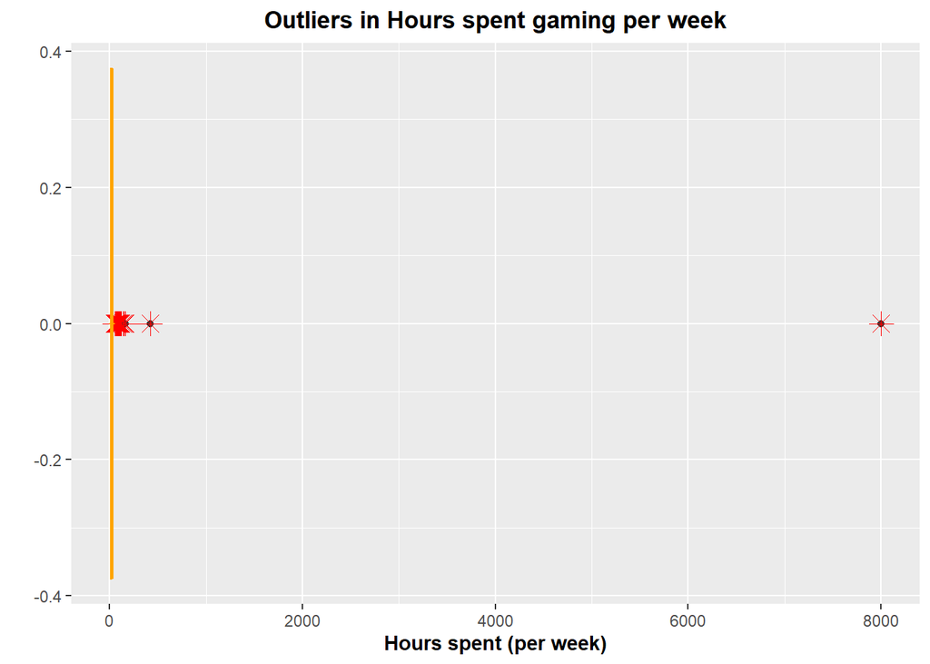

```r
ggplot(hrs_GAD_filtered, aes(x=Hours)) +
  geom_boxplot() +
  geom_boxplot(colour="orange", fill="#7777cc", outlier.colour="red", outlier.shape=8, outlier.size=4) +
  labs(title="Outliers in Hours spent gaming per week", x="Hours spent (per week)", y = "") +
  theme(
    plot.title = element_text(hjust = 0.5, face = "bold"),  # Center and bold title
    axis.title.x = element_text(hjust = 0.5, face = "bold"), # Bold and center x-axis label
    axis.title.y = element_text(hjust = 0.5, face = "bold")  # Bold and center y-axis label
  )
```

# Removing outliers in Hours and creating new dataset

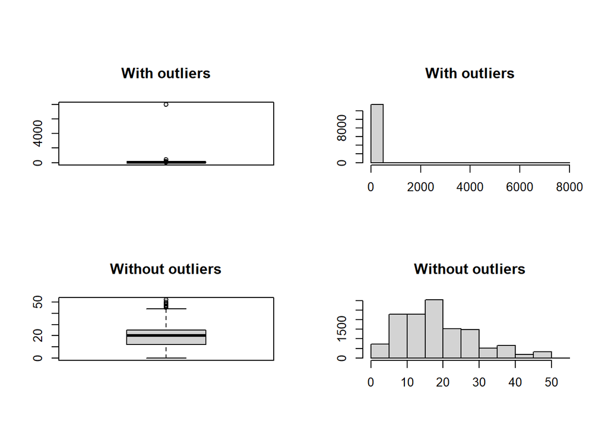

```
## Outliers identified: 418
## Proportion (%) of outliers: 3.2
## Mean of the outliers: 88.9
## Mean without removing outliers: 22.25
## Mean if we remove outliers: 20.11
## Outliers successfully removed
```

```r
# Define the outlierKD2 function
outlierKD2 <- function(dt, var, rm = TRUE, boxplt = TRUE, qqplt = TRUE) {
  var_name <- eval(substitute(var),eval(dt))
  na1 <- sum(is.na(var_name))
  m1 <- mean(var_name, na.rm = TRUE)

  # Generate plots (boxplot and histogram)
  if (boxplt) {
    par(mfrow = c(2, 2), oma = c(0, 0, 3, 0))
    boxplot(var_name, main = "With outliers")
    hist(var_name, main = "With outliers", xlab = NA, ylab = NA)
  }

  outlier <- boxplot.stats(var_name)$out
  mo <- mean(outlier)

  var_name <- ifelse(var_name %in% outlier, NA, var_name)

  if (boxplt) {
    boxplot(var_name, main = "Without outliers")
    hist(var_name, main = "Without outliers", xlab = NA, ylab = NA)
  }

  # Generate QQ plot if requested
  if (qqplt) {
    qqnorm(var_name)
    qqline(var_name)
  }

  na2 <- sum(is.na(var_name))

  cat("Outliers identified:", na2 - na1, "\n")
  cat("Proportion (%) of outliers:", round((na2 - na1) / sum(!is.na(var_name)) * 100, 1), "\n")
  cat("Mean of the outliers:", round(mo, 2), "\n")
  m2 <- mean(var_name, na.rm = TRUE)
  cat("Mean without removing outliers:", round(m1, 2), "\n")
  cat("Mean if we remove outliers:", round(m2, 2), "\n")

  # Option to remove outliers (replace with NA)
  if (rm) {
    dt[[as.character(substitute(var))]] <- invisible(var_name)
    assign(as.character(as.list(match.call())$dt), dt, envir = .GlobalEnv)
    cat("Outliers successfully removed\n")
    return(invisible(dt))
  } else {
    cat("Nothing changed\n")
    return(invisible(var_name))
  }
}

# Assume hrs_GAD_filtered is your dataset
# Use outlierKD2 to remove outliers from 'Hours'
hrs_GAD_filtered_clean <- outlierKD2(hrs_GAD_filtered, Hours, rm = TRUE, boxplt = TRUE, qqplt = TRUE)
```

```r
# Check the structure of the cleaned dataset
str(hrs_GAD_filtered_clean)
```

```
## 'data.frame':    13464 obs. of  9 variables:
##  $ Hours: int  15 8 0 20 20 4 30 25 2 25 ...
##  $ GAD1 : int  0 1 0 0 2 0 0 0 2 2 ...
##  $ GAD2 : int  0 2 2 0 1 0 0 0 3 1 ...
##  $ GAD3 : int  0 2 2 0 2 0 0 0 2 2 ...
##  $ GAD4 : int  0 2 0 0 2 0 0 0 2 2 ...
##  $ GAD5 : int  1 0 0 0 2 0 0 0 0 2 ...
##  $ GAD6 : int  0 1 3 0 3 1 0 0 1 1 ...
##  $ GAD7 : int  0 0 1 0 2 0 0 0 2 0 ...
##  $ GAD_T: int  1 8 8 0 14 1 0 0 12 10 ...
```

```r
# Summary to verify the changes
summary(hrs_GAD_filtered_clean)
```

```
##      Hours            GAD1            GAD2             GAD3
##  Min.   : 0.00   Min.   :0.000   Min.   :0.0000   Min.   :0.0000
##  1st Qu.:12.00   1st Qu.:0.000   1st Qu.:0.0000   1st Qu.:0.0000
##  Median :20.00   Median :1.000   Median :0.0000   Median :1.0000
##  Mean   :20.11   Mean   :0.861   Mean   :0.6734   Mean   :0.9658
##  3rd Qu.:25.00   3rd Qu.:1.000   3rd Qu.:1.0000   3rd Qu.:2.0000
##  Max.   :52.00   Max.   :3.000   Max.   :3.0000   Max.   :3.0000
##  NA's   :448
##       GAD4             GAD5            GAD6            GAD7
##  Min.   :0.0000   Min.   :0.000   Min.   :0.000   Min.   :0.0000
##  1st Qu.:0.0000   1st Qu.:0.000   1st Qu.:0.000   1st Qu.:0.0000
##  Median :0.0000   Median :0.000   Median :1.000   Median :0.0000
##  Mean   :0.7241   Mean   :0.488   Mean   :0.911   Mean   :0.5888
##  3rd Qu.:1.0000   3rd Qu.:1.000   3rd Qu.:1.000   3rd Qu.:1.0000
##  Max.   :3.0000   Max.   :3.000   Max.   :3.000   Max.   :3.0000
##
##      GAD_T
##  Min.   : 0.000
##  1st Qu.: 2.000
##  Median : 4.000
##  Mean   : 5.212
##  3rd Qu.: 8.000
##  Max.   :21.000
##
```

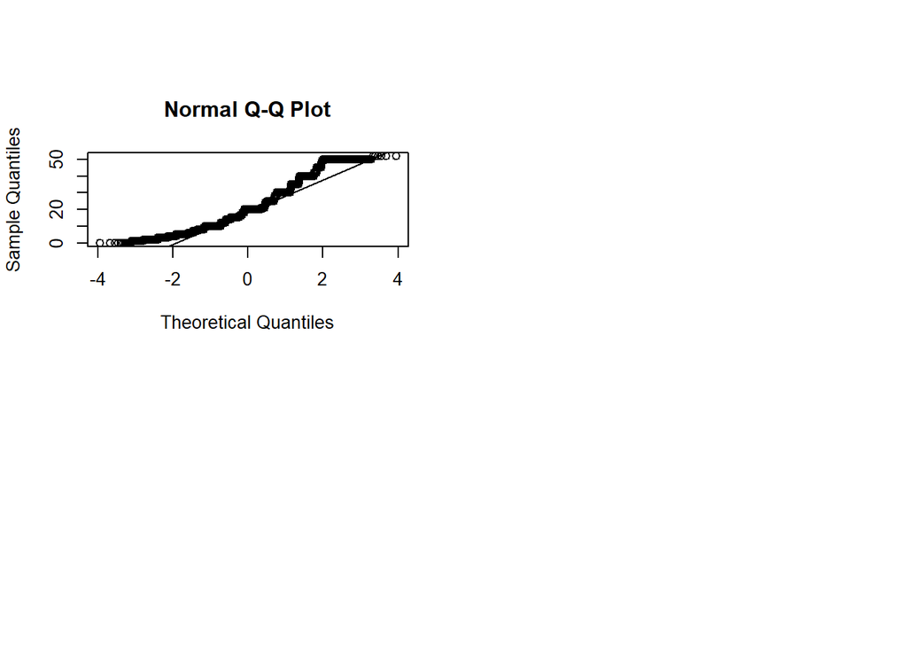

# Create a histogram and boxplot for Cleaned Hours

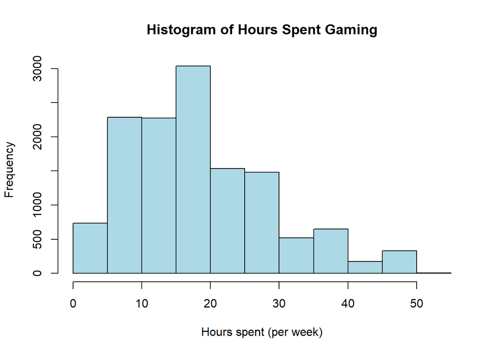

```r
hist(hrs_GAD_filtered_clean$Hours, main = "Histogram of Hours Spent Gaming", xlab = "Hours spent (per week)", col = "lightblue")
```

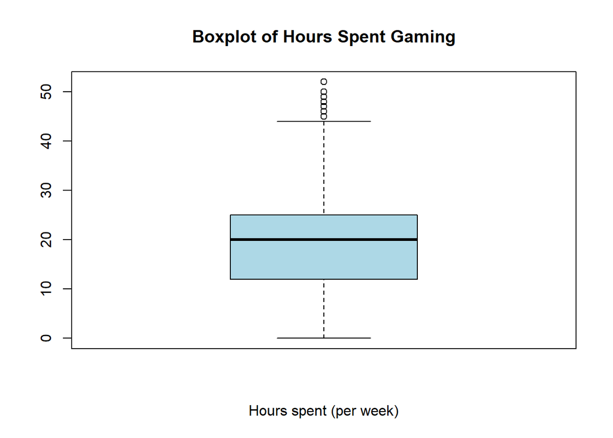

```r
boxplot(hrs_GAD_filtered_clean$Hours, main = "Boxplot of Hours Spent Gaming", xlab = "Hours spent (per week)", col = "lightblue")
```

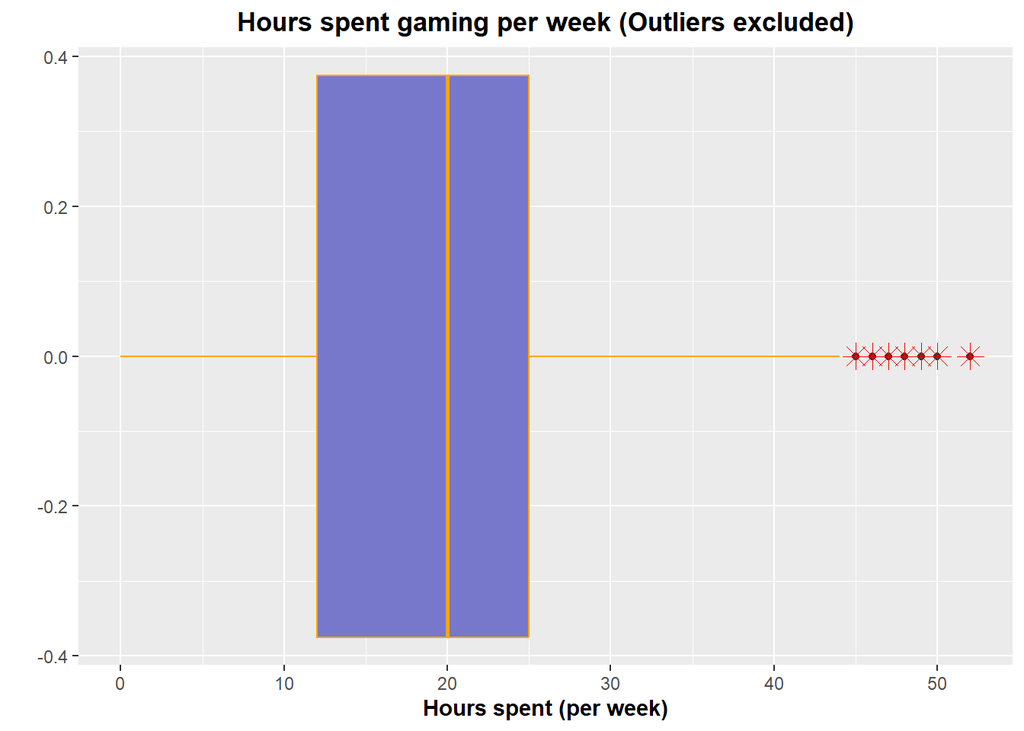

```r
ggplot(hrs_GAD_filtered_clean, aes(x=hrs_GAD_filtered_clean$Hours)) +
  geom_boxplot() +
  geom_boxplot(colour="orange", fill="#7777cc", outlier.colour="red", outlier.shape=8, outlier.size=4) +
  labs(title="Hours spent gaming per week (Outliers excluded)", x="Hours spent (per week)", y = "") +
  theme(
    plot.title = element_text(hjust = 0.5, face = "bold"),  # Center and bold title
    axis.title.x = element_text(hjust = 0.5, face = "bold"), # Bold and center x-axis label
    axis.title.y = element_text(hjust = 0.5, face = "bold")  # Bold and center y-axis label
  )
```

# Finding outliers in Age

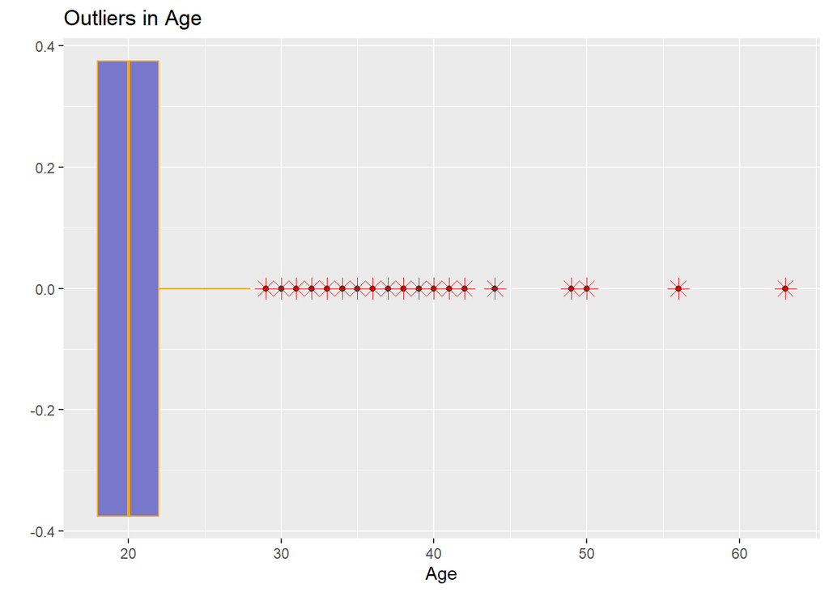

```r
ggplot(gaming_data, aes(x=Age)) +
  geom_boxplot() +
  geom_boxplot( colour="orange", fill="#7777cc", outlier.colour="red", outlier.shape=8, outlier.size=4) +
  labs(title="Outliers in Age", x="Age", y = "")
```

# Removing outliers in Age and creating new dataset

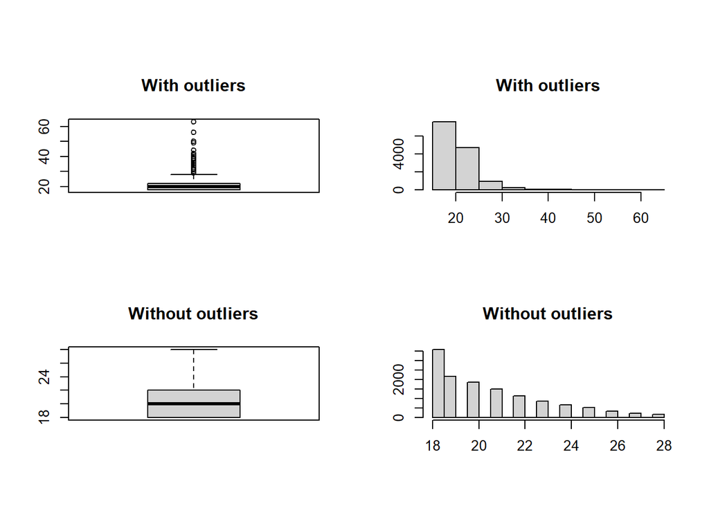

```
## Outliers identified: 448
## Proportion (%) of outliers: 3.4
## Mean of the outliers: 31.96
## Mean without removing outliers: 20.93
## Mean if we remove outliers: 20.55
## Outliers successfully removed
```

```r
# Define the outlierKD2 function (assuming it's not already defined in your environment)
outlierKD2 <- function(dt, var, rm = TRUE, boxplt = TRUE, qqplt = TRUE) {
  var_name <- eval(substitute(var),eval(dt))
  na1 <- sum(is.na(var_name))
  m1 <- mean(var_name, na.rm = TRUE)

  # Generate plots (boxplot and histogram)
  if (boxplt) {
    par(mfrow = c(2, 2), oma = c(0, 0, 3, 0))
    boxplot(var_name, main = "With outliers")
    hist(var_name, main = "With outliers", xlab = NA, ylab = NA)
  }

  outlier <- boxplot.stats(var_name)$out
  mo <- mean(outlier)

  var_name <- ifelse(var_name %in% outlier, NA, var_name)

  if (boxplt) {
    boxplot(var_name, main = "Without outliers")
    hist(var_name, main = "Without outliers", xlab = NA, ylab = NA)
  }

  # Generate QQ plot if requested
  if (qqplt) {
    qqnorm(var_name)
    qqline(var_name)
  }

  na2 <- sum(is.na(var_name))

  cat("Outliers identified:", na2 - na1, "\n")
  cat("Proportion (%) of outliers:", round((na2 - na1) / sum(!is.na(var_name)) * 100, 1), "\n")
  cat("Mean of the outliers:", round(mo, 2), "\n")
  m2 <- mean(var_name, na.rm = TRUE)
  cat("Mean without removing outliers:", round(m1, 2), "\n")
  cat("Mean if we remove outliers:", round(m2, 2), "\n")

  # Option to remove outliers (replace with NA)
  if (rm) {
    dt[[as.character(substitute(var))]] <- invisible(var_name)
    assign(as.character(as.list(match.call())$dt), dt, envir = .GlobalEnv)
    cat("Outliers successfully removed\n")
    return(invisible(dt))
  } else {
    cat("Nothing changed\n")
    return(invisible(var_name))
  }
}

# Assume gaming_data is your dataset
# Use outlierKD2 to remove outliers from 'Age'
gaming_data_clean <- outlierKD2(gaming_data, Age, rm = TRUE, boxplt = TRUE, qqplt = TRUE)
```

```r
# Check the structure of the cleaned dataset
str(gaming_data_clean)
```

```
## 'data.frame':    13464 obs. of  55 variables:
##  $ S..No.         : int  1 2 3 4 5 6 7 8 9 10 ...
##  $ Timestamp      : num  42052 42052 42052 42052 42052 ...
##  $ GAD1           : int  0 1 0 0 2 0 0 0 2 2 ...
##  $ GAD2           : int  0 2 2 0 1 0 0 0 3 1 ...
##  $ GAD3           : int  0 2 2 0 2 0 0 0 2 2 ...
##  $ GAD4           : int  0 2 0 0 2 0 0 0 2 2 ...
##  $ GAD5           : int  1 0 0 0 2 0 0 0 0 2 ...
##  $ GAD6           : int  0 1 3 0 3 1 0 0 1 1 ...
##  $ GAD7           : int  0 0 1 0 2 0 0 0 2 0 ...
##  $ GADE           : chr  "Not difficult at all" "Somewhat difficult" "Not difficult at all" "Not difficult at all" ...
##  $ SWL1           : int  3 3 2 2 2 3 3 3 2 3 ...
##  $ SWL2           : int  5 5 6 5 2 5 4 6 3 3 ...
##  $ SWL3           : int  5 2 5 5 4 3 4 4 3 3 ...
##  $ SWL4           : int  5 5 2 3 5 3 3 3 3 2 ...
```

[output cut: 41 more lines]

```r
# Summary to verify the changes
summary(gaming_data_clean)
```

```
##      S..No.        Timestamp          GAD1            GAD2
##  Min.   :    1   Min.   :42052   Min.   :0.000   Min.   :0.0000
##  1st Qu.: 3533   1st Qu.:42055   1st Qu.:0.000   1st Qu.:0.0000
##  Median : 7088   Median :42055   Median :1.000   Median :0.0000
##  Mean   : 7097   Mean   :42055   Mean   :0.861   Mean   :0.6734
##  3rd Qu.:10654   3rd Qu.:42055   3rd Qu.:1.000   3rd Qu.:1.0000
##  Max.   :14250   Max.   :42058   Max.   :3.000   Max.   :3.0000
##
##       GAD3             GAD4             GAD5            GAD6
##  Min.   :0.0000   Min.   :0.0000   Min.   :0.000   Min.   :0.000
##  1st Qu.:0.0000   1st Qu.:0.0000   1st Qu.:0.000   1st Qu.:0.000
##  Median :1.0000   Median :0.0000   Median :0.000   Median :1.000
##  Mean   :0.9658   Mean   :0.7241   Mean   :0.488   Mean   :0.911
##  3rd Qu.:2.0000   3rd Qu.:1.0000   3rd Qu.:1.000   3rd Qu.:1.000
##  Max.   :3.0000   Max.   :3.0000   Max.   :3.000   Max.   :3.000
##
##       GAD7            GADE                SWL1           SWL2
##  Min.   :0.0000   Length:13464       Min.   :1.00   Min.   :1.000
##  1st Qu.:0.0000   Class :character   1st Qu.:2.00   1st Qu.:3.000
##  Median :0.0000   Mode  :character   Median :4.00   Median :5.000
##  Mean   :0.5888                      Mean   :3.72   Mean   :4.602
##  3rd Qu.:1.0000                      3rd Qu.:5.00   3rd Qu.:6.000
##  Max.   :3.0000                      Max.   :7.00   Max.   :7.000
##
##       SWL3            SWL4            SWL5           Game
##  Min.   :1.000   Min.   :1.000   Min.   :1.000   Length:13464
##  1st Qu.:3.000   1st Qu.:2.000   1st Qu.:2.000   Class :character
##  Median :5.000   Median :4.000   Median :3.000   Mode  :character
##  Mean   :4.345   Mean   :3.762   Mean   :3.359
##  3rd Qu.:6.000   3rd Qu.:5.000   3rd Qu.:5.000
##  Max.   :7.000   Max.   :7.000   Max.   :7.000
##
##    Platform             Hours           earnings           whyplay
##  Length:13464       Min.   :   0.00   Length:13464       Length:13464
##  Class :character   1st Qu.:  12.00   Class :character   Class :character
##  Mode  :character   Median :  20.00   Mode  :character   Mode  :character
##                     Mean   :  22.25
##                     3rd Qu.:  28.00
##                     Max.   :8000.00
##                     NA's   :30
```

[output cut: 57 more lines]

```
##  Length:13464       Length:13464       Min.   : 0.000   Min.   : 5.00
##  Class :character   Class :character   1st Qu.: 2.000   1st Qu.:14.00
##  Mode  :character   Mode  :character   Median : 4.000   Median :20.00
##                                        Mean   : 5.212   Mean   :19.79
##                                        3rd Qu.: 8.000   3rd Qu.:26.00
##                                        Max.   :21.000   Max.   :35.00
##
##      SPIN_T      Residence_ISO3     Birthplace_ISO3
##  Min.   : 0.00   Length:13464       Length:13464
##  1st Qu.: 9.00   Class :character   Class :character
##  Median :17.00   Mode  :character   Mode  :character
##  Mean   :19.85
##  3rd Qu.:28.00
##  Max.   :68.00
##  NA's   :650
```

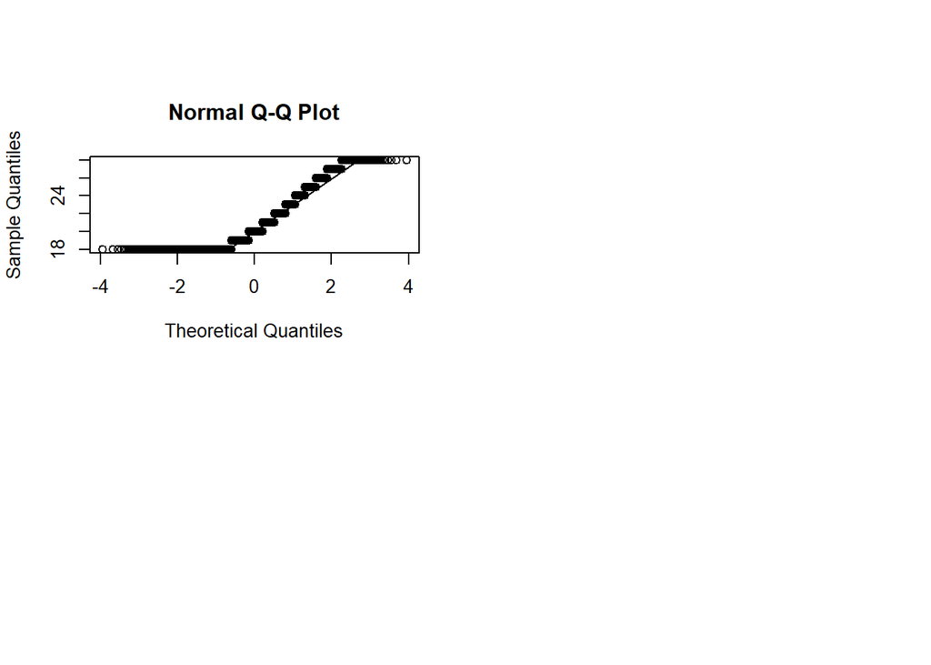

# Create a histogram and boxplot for Cleaned Age

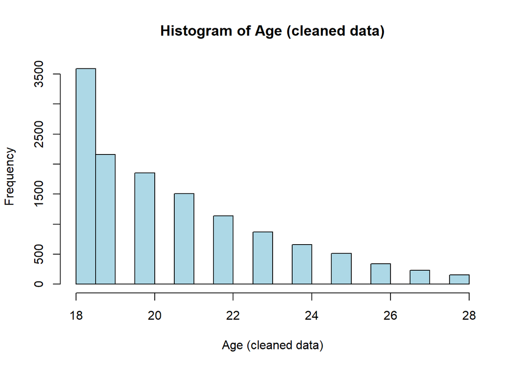

```r
hist(gaming_data_clean$Age, main = "Histogram of Age (cleaned data)", xlab = "Age (cleaned data)", col = "lightblue")
```

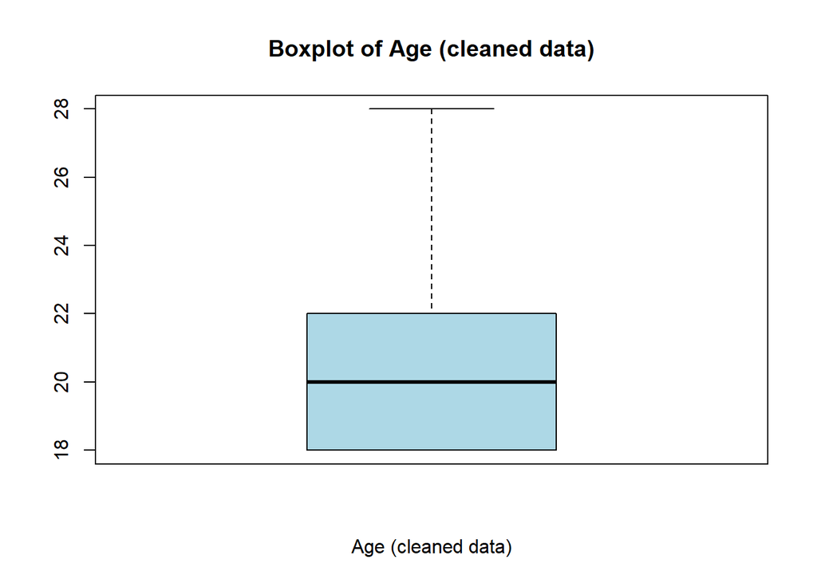

```r
boxplot(gaming_data_clean$Age, main = "Boxplot of Age (cleaned data)", xlab = "Age (cleaned data)", col = "lightblue")
```

# Finding outliers in Streams

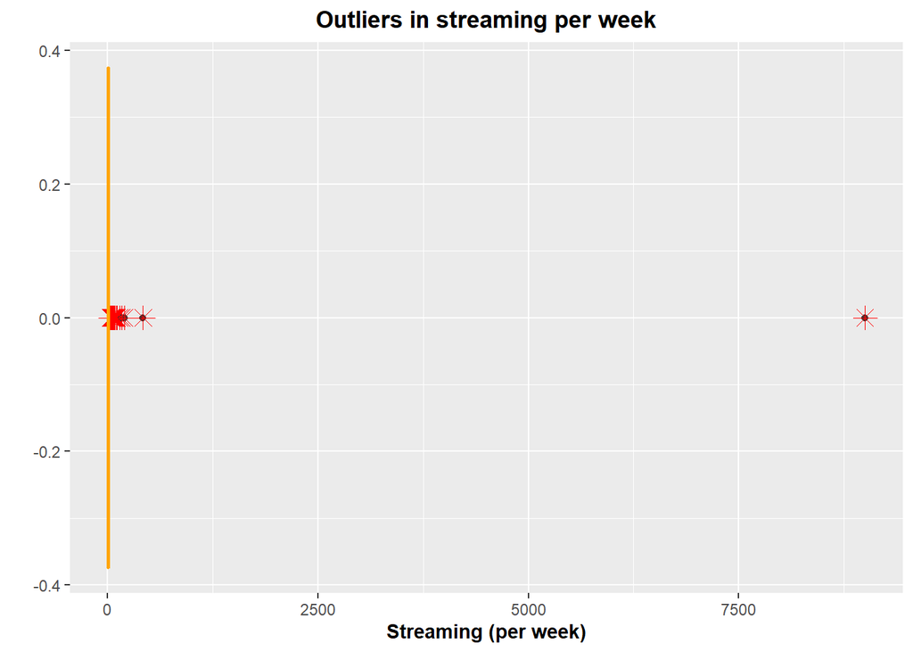

```r
ggplot(gaming_data, aes(x=streams)) +
  geom_boxplot() +
  geom_boxplot(colour="orange", fill="#7777cc", outlier.colour="red", outlier.shape=8, outlier.size=4) +
  labs(title="Outliers in streaming per week", x="Streaming (per week)", y = "") +
  theme(
    plot.title = element_text(hjust = 0.5, face = "bold"),  # Center and bold title
    axis.title.x = element_text(hjust = 0.5, face = "bold"), # Bold and center x-axis label
    axis.title.y = element_text(hjust = 0.5, face = "bold")  # Bold and center y-axis label
  )
```

# Removing outliers in Streams and creating new dataset

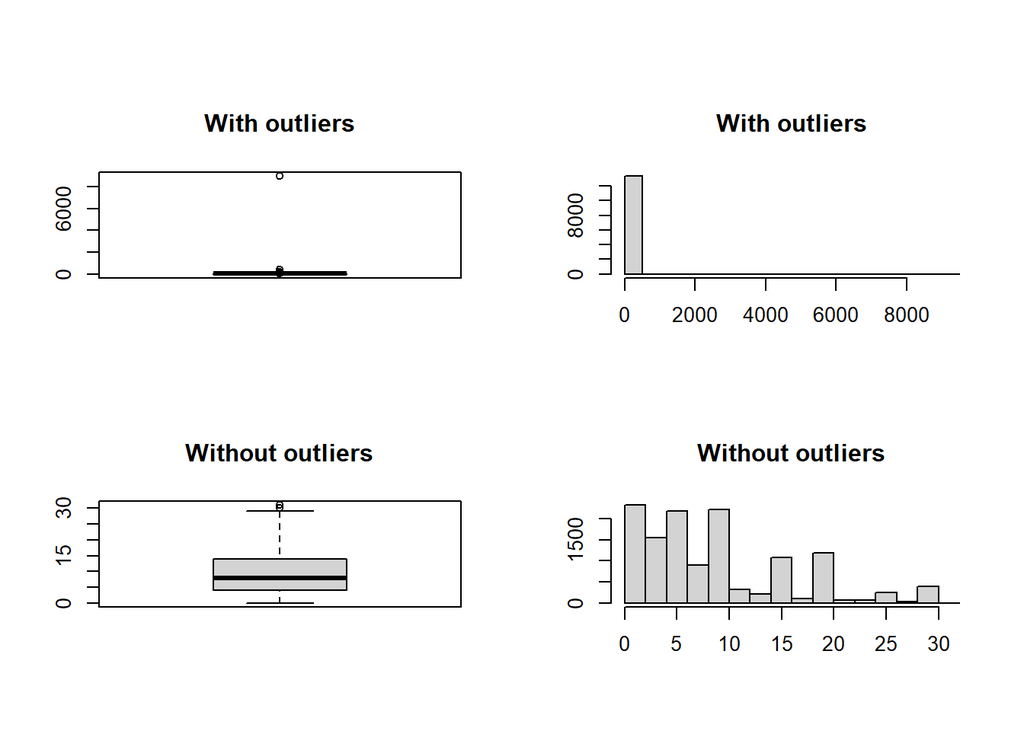

```
## Outliers identified: 448
## Proportion (%) of outliers: 3.5
## Mean of the outliers: 67.93
## Mean without removing outliers: 11.23
## Mean if we remove outliers: 9.27
## Outliers successfully removed
```

```r
# Define the outlierKD2 function
outlierKD2 <- function(dt, var, rm = TRUE, boxplt = TRUE, qqplt = TRUE) {
  var_name <- eval(substitute(var),eval(dt))
  na1 <- sum(is.na(var_name))
  m1 <- mean(var_name, na.rm = TRUE)

  # Generate plots (boxplot and histogram)
  if (boxplt) {
    par(mfrow = c(2, 2), oma = c(0, 0, 3, 0))
    boxplot(var_name, main = "With outliers")
    hist(var_name, main = "With outliers", xlab = NA, ylab = NA)
  }

  outlier <- boxplot.stats(var_name)$out
  mo <- mean(outlier)

  var_name <- ifelse(var_name %in% outlier, NA, var_name)

  if (boxplt) {
    boxplot(var_name, main = "Without outliers")
    hist(var_name, main = "Without outliers", xlab = NA, ylab = NA)
  }

  # Generate QQ plot if requested
  if (qqplt) {
    qqnorm(var_name)
    qqline(var_name)
  }

  na2 <- sum(is.na(var_name))

  cat("Outliers identified:", na2 - na1, "\n")
  cat("Proportion (%) of outliers:", round((na2 - na1) / sum(!is.na(var_name)) * 100, 1), "\n")
  cat("Mean of the outliers:", round(mo, 2), "\n")
  m2 <- mean(var_name, na.rm = TRUE)
  cat("Mean without removing outliers:", round(m1, 2), "\n")
  cat("Mean if we remove outliers:", round(m2, 2), "\n")

  # Option to remove outliers (replace with NA)
  if (rm) {
    dt[[as.character(substitute(var))]] <- invisible(var_name)
    assign(as.character(as.list(match.call())$dt), dt, envir = .GlobalEnv)
    cat("Outliers successfully removed\n")
    return(invisible(dt))
  } else {
    cat("Nothing changed\n")
    return(invisible(var_name))
  }
}

# Use outlierKD2 to remove outliers from 'streams'
gaming_data_clean <- outlierKD2(gaming_data, streams, rm = TRUE, boxplt = TRUE, qqplt = TRUE)
```

```r
# Check the structure of the cleaned dataset
str(gaming_data_clean)
```

```
## 'data.frame':    13464 obs. of  55 variables:
##  $ S..No.         : int  1 2 3 4 5 6 7 8 9 10 ...
##  $ Timestamp      : num  42052 42052 42052 42052 42052 ...
##  $ GAD1           : int  0 1 0 0 2 0 0 0 2 2 ...
##  $ GAD2           : int  0 2 2 0 1 0 0 0 3 1 ...
##  $ GAD3           : int  0 2 2 0 2 0 0 0 2 2 ...
##  $ GAD4           : int  0 2 0 0 2 0 0 0 2 2 ...
##  $ GAD5           : int  1 0 0 0 2 0 0 0 0 2 ...
##  $ GAD6           : int  0 1 3 0 3 1 0 0 1 1 ...
##  $ GAD7           : int  0 0 1 0 2 0 0 0 2 0 ...
##  $ GADE           : chr  "Not difficult at all" "Somewhat difficult" "Not difficult at all" "Not difficult at all" ...
##  $ SWL1           : int  3 3 2 2 2 3 3 3 2 3 ...
##  $ SWL2           : int  5 5 6 5 2 5 4 6 3 3 ...
##  $ SWL3           : int  5 2 5 5 4 3 4 4 3 3 ...
##  $ SWL4           : int  5 5 2 3 5 3 3 3 3 2 ...
```

[output cut: 41 more lines]

```r
# Summary to verify the changes
summary(gaming_data_clean)
```

```
##      S..No.        Timestamp          GAD1            GAD2
##  Min.   :    1   Min.   :42052   Min.   :0.000   Min.   :0.0000
##  1st Qu.: 3533   1st Qu.:42055   1st Qu.:0.000   1st Qu.:0.0000
##  Median : 7088   Median :42055   Median :1.000   Median :0.0000
##  Mean   : 7097   Mean   :42055   Mean   :0.861   Mean   :0.6734
##  3rd Qu.:10654   3rd Qu.:42055   3rd Qu.:1.000   3rd Qu.:1.0000
##  Max.   :14250   Max.   :42058   Max.   :3.000   Max.   :3.0000
##
##       GAD3             GAD4             GAD5            GAD6
##  Min.   :0.0000   Min.   :0.0000   Min.   :0.000   Min.   :0.000
##  1st Qu.:0.0000   1st Qu.:0.0000   1st Qu.:0.000   1st Qu.:0.000
##  Median :1.0000   Median :0.0000   Median :0.000   Median :1.000
##  Mean   :0.9658   Mean   :0.7241   Mean   :0.488   Mean   :0.911
##  3rd Qu.:2.0000   3rd Qu.:1.0000   3rd Qu.:1.000   3rd Qu.:1.000
##  Max.   :3.0000   Max.   :3.0000   Max.   :3.000   Max.   :3.000
##
##       GAD7            GADE                SWL1           SWL2
##  Min.   :0.0000   Length:13464       Min.   :1.00   Min.   :1.000
##  1st Qu.:0.0000   Class :character   1st Qu.:2.00   1st Qu.:3.000
##  Median :0.0000   Mode  :character   Median :4.00   Median :5.000
##  Mean   :0.5888                      Mean   :3.72   Mean   :4.602
##  3rd Qu.:1.0000                      3rd Qu.:5.00   3rd Qu.:6.000
##  Max.   :3.0000                      Max.   :7.00   Max.   :7.000
##
##       SWL3            SWL4            SWL5           Game
##  Min.   :1.000   Min.   :1.000   Min.   :1.000   Length:13464
##  1st Qu.:3.000   1st Qu.:2.000   1st Qu.:2.000   Class :character
##  Median :5.000   Median :4.000   Median :3.000   Mode  :character
##  Mean   :4.345   Mean   :3.762   Mean   :3.359
##  3rd Qu.:6.000   3rd Qu.:5.000   3rd Qu.:5.000
##  Max.   :7.000   Max.   :7.000   Max.   :7.000
##
##    Platform             Hours           earnings           whyplay
##  Length:13464       Min.   :   0.00   Length:13464       Length:13464
##  Class :character   1st Qu.:  12.00   Class :character   Class :character
##  Mode  :character   Median :  20.00   Mode  :character   Mode  :character
##                     Mean   :  22.25
##                     3rd Qu.:  28.00
##                     Max.   :8000.00
##                     NA's   :30
```

[output cut: 57 more lines]

```
##  Length:13464       Length:13464       Min.   : 0.000   Min.   : 5.00
##  Class :character   Class :character   1st Qu.: 2.000   1st Qu.:14.00
##  Mode  :character   Mode  :character   Median : 4.000   Median :20.00
##                                        Mean   : 5.212   Mean   :19.79
##                                        3rd Qu.: 8.000   3rd Qu.:26.00
##                                        Max.   :21.000   Max.   :35.00
##
##      SPIN_T      Residence_ISO3     Birthplace_ISO3
##  Min.   : 0.00   Length:13464       Length:13464
##  1st Qu.: 9.00   Class :character   Class :character
##  Median :17.00   Mode  :character   Mode  :character
##  Mean   :19.85
##  3rd Qu.:28.00
##  Max.   :68.00
##  NA's   :650
```

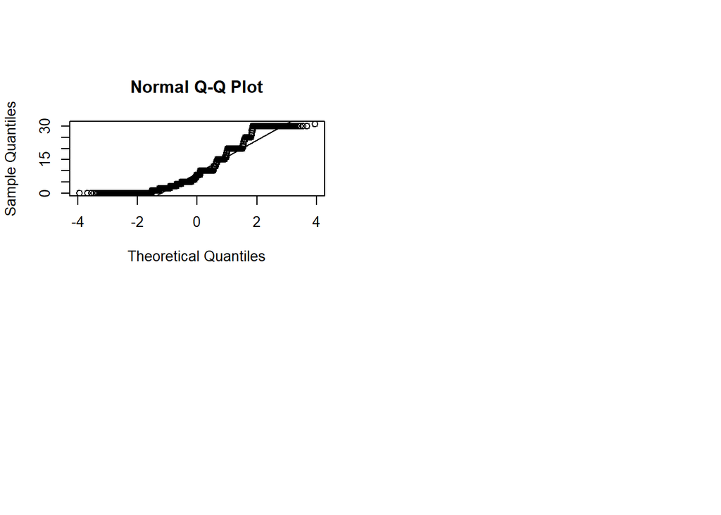

# Create a histogram and boxplot for Cleaned Streams

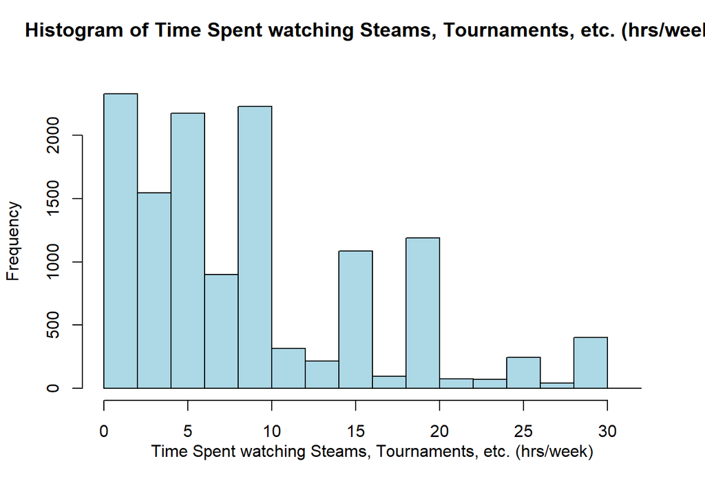

```r
hist(gaming_data_clean$streams, main = "Histogram of Time Spent watching Steams, Tournaments, etc. (hrs/week)
", xlab = "Time Spent watching Steams, Tournaments, etc. (hrs/week)
 ", col = "lightblue")
```

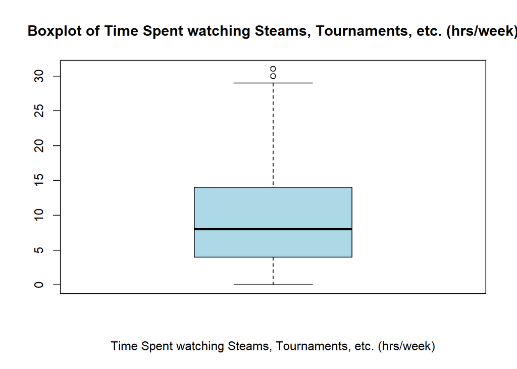

```r
boxplot(gaming_data_clean$streams, main = "Boxplot of Time Spent watching Steams, Tournaments, etc. (hrs/week)", xlab = "Time Spent watching Steams, Tournaments, etc. (hrs/week)", col = "lightblue")
```

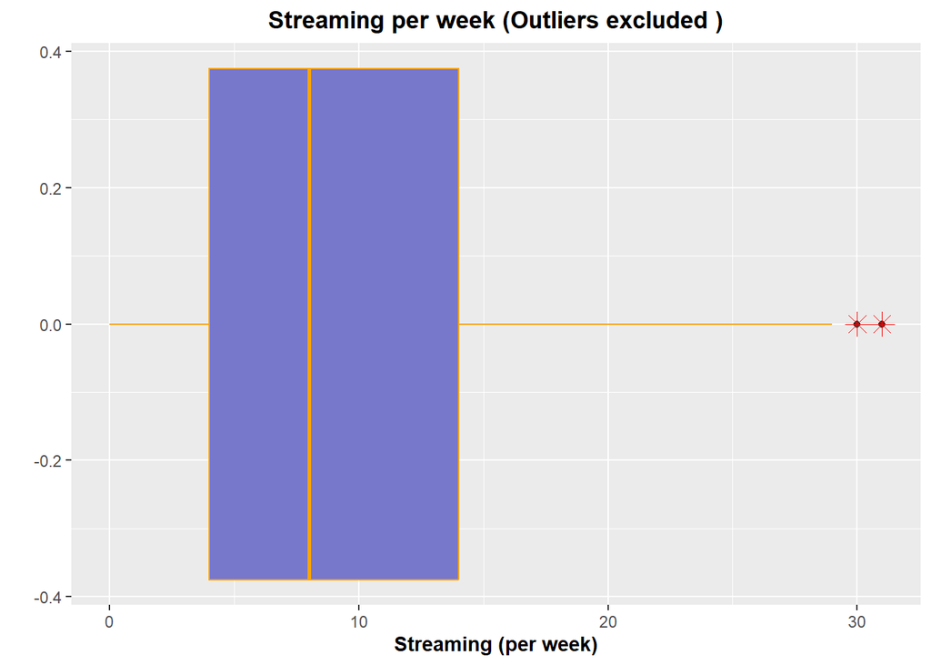

```r
ggplot(gaming_data_clean, aes(x=gaming_data_clean$streams)) +
  geom_boxplot() +
  geom_boxplot(colour="orange", fill="#7777cc", outlier.colour="red", outlier.shape=8, outlier.size=4) +
  labs(title="Streaming per week (Outliers excluded )", x="Streaming (per week)", y = "") +
  theme(
    plot.title = element_text(hjust = 0.5, face = "bold"),  # Center and bold title
    axis.title.x = element_text(hjust = 0.5, face = "bold"), # Bold and center x-axis label
    axis.title.y = element_text(hjust = 0.5, face = "bold")  # Bold and center y-axis label
  )
```

# Cleaning the Playstyle Data and Whyplay

# Playstyle cleaning

```r
# Function to standardize Playstyle responses
standardize_playstyle <- function(playstyle) {
  playstyle <- trimws(tolower(playstyle))  # Normalize to lowercase and trim whitespace

  # Standardize to SinglePlayer category
  if (str_detect(playstyle, "single|solo|1v1 matchmaking|one person|yolo queue") ||
      playstyle %in% c("singleplayer",
                       "singleplayer - online",
                       "single player - speedrunning",
                       "singleplayer, but streaming",
                       "solo q",
                       "soloqueue",
                       "solo que",
                       "by myself/with 1 friend whilst communicating our soloq experiences with each other over skype")) {
    return("SinglePlayer")
  }

  # Standardize to Both Type category
  if (str_detect(playstyle, "mix|mixed|mixture|both|all|sometimes|everything|sometimes solo|a combination|usually combination of all|an equal mix|last 3 options") ||
      playstyle %in% c("mutliplayer - a mix of friends/strangers.",
                       "mix of real life friends and online acquaintances",
                       "a mixture of all of them",
                       "mix of online teammates and real life friends",
                       "mix between singleplayer and mutliplayer with real life friends",
                       "multiplayer - online - mix of real life friends and strangers",
                       "sometimes alone (ranked), sometimes with friends. everytime there are strangers in my game ofc",
                       "used to be the last option only, but in the last two weeks only singleplayer",
                       "its really a bit of all",
                       "everything from above in the same amount",
                       "single/multi same amount",
                       "its a mixture of both single player and online with strangers",
                       "singleplayer and multiplayer online with strangers",
                       "i'm versatile",
                       "friends online, also solo player",
                       "everything almost equally",
                       "singleplayer - online - talking with real life friends",
                       "singleplayer and multiplayer with real life friends or strangers",
                       "duo queue with one good friend, else solo",
                       "depends",
                       "its pretty 33%: sp(ksp), mp friends(cs), mp strangers(lol)",
                       "all of em ?",
                       "mix of all",
                       "both single and online with friends",
                       "both multi- and singleplayer with both friends and strangers",
                       "with all the above")) {
    return("Both Type")
  }

  # Default to Multiplayer for all other responses
  return("Multiplayer")
}

# Apply the cleaning function to the 'Playstyle' column
gaming_data$Playstyle <- sapply(gaming_data$Playstyle, standardize_playstyle)

# Count the occurrences of each standardized Playstyle
playstyle_counts <- as.data.frame(table(gaming_data$Playstyle))

# Print the counts for verification
print(playstyle_counts)
```

```
##           Var1  Freq
## 1    Both Type   105
## 2  Multiplayer 12556
## 3 SinglePlayer   803
```

# whyplay cleaning

```r
clean_responses <- function(response) {
  response <- trimws(tolower(response))  # Normalize to lowercase and trim whitespace

  # Check for exact matches first
  if (response %in% c("winning", "improving", "relaxing", "having fun")) {
    return(response)
  }

  # Check for various conditions to set the response
  if (str_detect(response, "^a[\\s,\\.]", ) ||
      str_detect(response, "^1[\\s,\\.]", ) ||
      str_detect(response, "^all") ||
      str_detect(response, "^mix") ||
      str_detect(response, "combination") ||
      str_detect(response, "everything")) {
    return("all of the above")
  }

  if (str_detect(response, "distraction|escaping|escape|forget|hide|hiding|depression|boredom|bored|time|forgetting|distracting|doing something|getting away from real life|trying to get my mind off")) {
    return("escape")
  }

  if (str_detect(response, "improve|improving|learn|learning")) {
    return("improving")
  }

  if (str_detect(response, "well|perform|performing")) {
    return("winning")
  }

  if (str_detect(response, "social|socializing|friends|team|cooperating|i don't know anymore|occupied|making my brain go numb|the people i play with, the game is less important")) {
    return("social")
  }

  if (str_detect(response, "win|winning|beating|victory|competeing|competing|competition|conpeting")) {
    return("winning")
  }

  if (str_detect(response, "winning") && str_detect(response, "improving")) {
    return("mix")
  }

  if (str_detect(response, "relaxing") && str_detect(response, "fun")) {
    return("mix")
  }

  if (str_detect(response, "combination|all")) {
    return("mix")
  }

  if (str_detect(response, "fun")) {
    return("having fun")
  }

  # Default to original response if no condition is met
  return("bad response")
}

# Apply the cleaning function to the 'whyplay' column
gaming_data$cleaned_whyplay <- sapply(gaming_data$whyplay, clean_responses)

# Count the occurrences of each cleaned response
whyplay_counts <- as.data.frame(table(gaming_data$cleaned_whyplay))

# Print the counts for verification
print(whyplay_counts)
```

```
##               Var1 Freq
## 1 all of the above  131
## 2     bad response   52
## 3           escape   57
## 4       having fun 5293
## 5        improving 5068
## 6              mix   17
## 7         relaxing  654
## 8           social   26
## 9          winning 2166
```

## Chi-squared test for Playstyle and WhyPlay

Null hypothesis is that there is no relation. Alternate is that there is.

```r
# Create a contingency table between cleaned_whyplay and Playstyle
contingency_table <- table(gaming_data$Playstyle, gaming_data$cleaned_whyplay)

# Print the contingency table
print(contingency_table)
```

```
##
##                all of the above bad response escape having fun improving  mix
##   Both Type                  10            2      1         34        41    1
##   Multiplayer               117           44     49       4917      4787   12
##   SinglePlayer                4            6      7        342       240    4
##
##                relaxing social winning
##   Both Type           6      0      10
##   Multiplayer       552     25    2053
##   SinglePlayer       96      1     103
```

```r
chi_squared_test <- chisq.test(contingency_table)
print(chi_squared_test)
```

```
##
##  Pearson's Chi-squared test
##
## data:  contingency_table
## X-squared = 225.85, df = 16, p-value < 2.2e-16
```

##Barcharts #Playstyle based on why they play

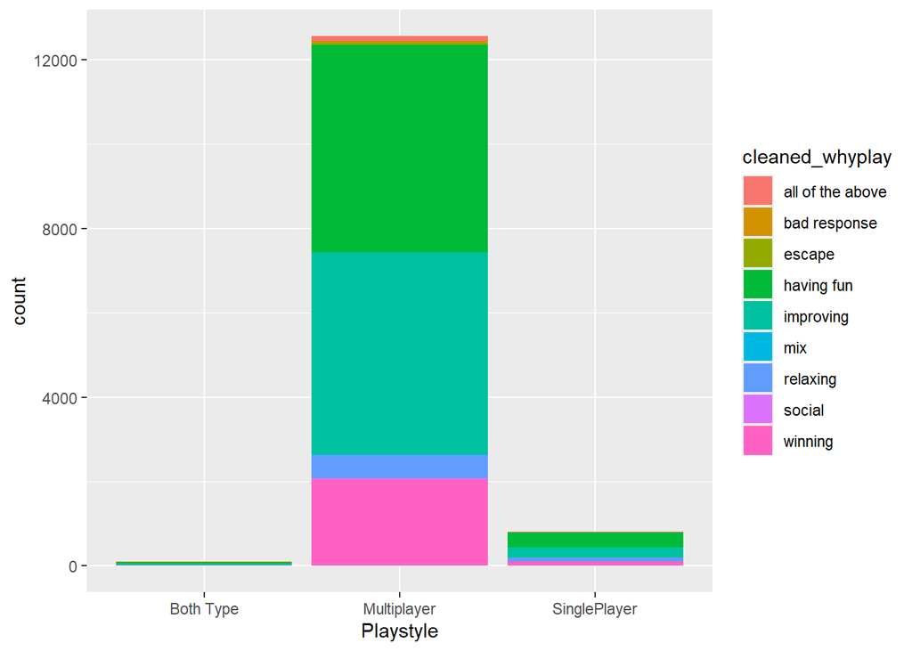

```r
ggplot(gaming_data, aes(x = Playstyle, fill = cleaned_whyplay)) +
geom_bar()
```

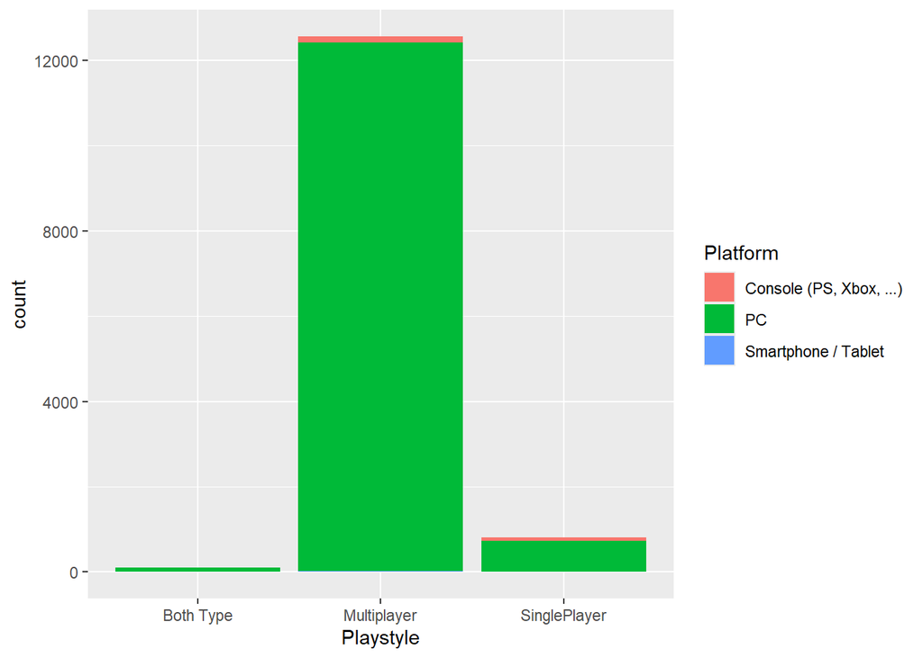

```r
ggplot(gaming_data, aes(x = Playstyle, fill = Platform)) +
geom_bar()
```

#Work status based on residence

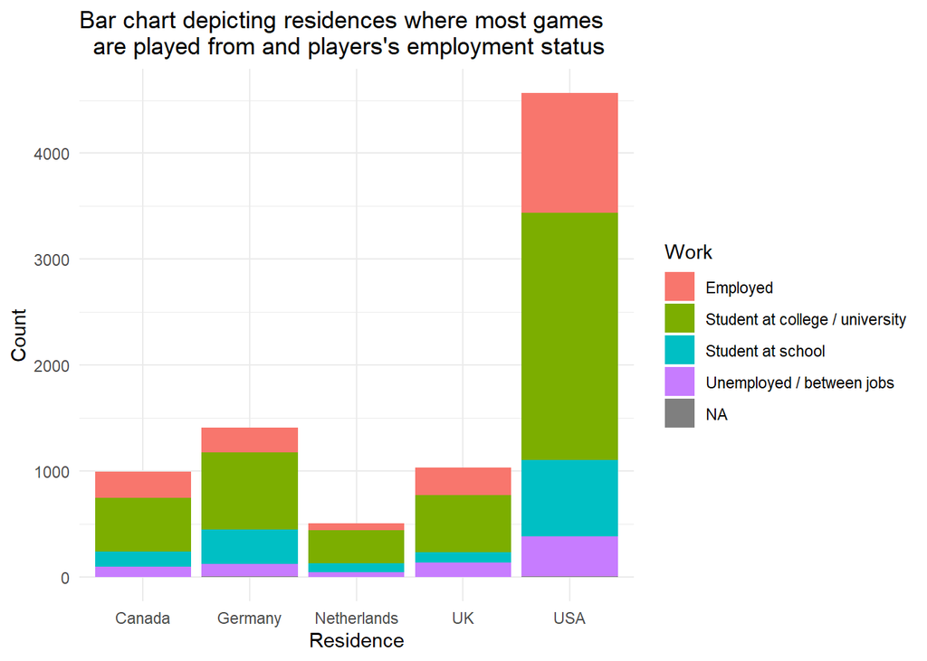

```r
# Summarize the data to get counts of each Residence
residence_counts <- gaming_data %>%
  group_by(Residence) %>%
  summarize(count = n())

# Filter for Residence values with counts greater than 500
filtered_residences <- residence_counts %>%
  filter(count > 500) %>%
  select(Residence)

# Join with the original data to keep only the relevant Residence values
filtered_data <- gaming_data %>%
  semi_join(filtered_residences, by = "Residence")

# Create the bar chart with the filtered data
ggplot(filtered_data, aes(x = Residence, fill = Work)) +
  geom_bar() +
  labs(title = "Bar chart depicting residences where most games
  are played from and players's employment status",
       x = "Residence",
       y = "Count") +
  theme_minimal()
```

# Turning into ordinal

```r
## Make raw scores ordinal
# Function to convert GAD_T to ordinal variable
convert_GAD <- function(score) {
  if (is.na(score)) return(NA)  # Handle NA values
  if (score >= 0 & score <= 4) {
    return("minimal anxiety")
  } else if (score >= 5 & score <= 9) {
    return("mild anxiety")
  } else if (score >= 10 & score <= 14) {
    return("moderate anxiety")
  } else if (score >= 15 & score <= 21) {
    return("severe anxiety")
  } else {
    return(NA)  # Handles scores outside defined range
  }
}

# Function to convert SWL_T to ordinal variable
convert_SWL <- function(score) {
  if (is.na(score)) return(NA)  # Handle NA values
  if (score >= 31 & score <= 35) {
    return("extremely satisfied")
  } else if (score >= 26 & score <= 30) {
    return("satisfied")
  } else if (score >= 21 & score <= 25) {
    return("slightly satisfied")
  } else if (score == 20) {
    return("neutral")
  } else if (score >= 15 & score <= 19) {
    return("slightly dissatisfied")
  } else if (score >= 10 & score <= 14) {
    return("dissatisfied")
  } else if (score >= 5 & score <= 9) {
    return("extremely dissatisfied")
  } else {
    return(NA)  # Handles scores outside defined range
  }
}

# Function to convert SPIN_T to ordinal variable
convert_SPIN <- function(score) {
  if (is.na(score)) return(NA)  # Handle NA values
  if (score >= 0 & score <= 20) {
    return("none")
  } else if (score >= 21 & score <= 30) {
    return("mild")
  } else if (score >= 31 & score <= 40) {
    return("moderate")
  } else if (score >= 41 & score <= 50) {
    return("severe")
  } else if (score >= 51 & score <= 68) {
    return("very severe")
  } else {
    return(NA)  # Handles scores outside defined range
  }
}


# Create new columns in the data frame
gaming_data$GAD_ord <- sapply(gaming_data$GAD_T, convert_GAD)
gaming_data$SWL_ord <- sapply(gaming_data$SWL_T, convert_SWL)
gaming_data$SPIN_ord <- sapply(gaming_data$SPIN_T, convert_SPIN)

#make values ordinal (min to max)
gaming_data$GAD_ord <- factor(gaming_data$GAD_ord,
                     levels = c("minimal anxiety", "mild anxiety", "moderate anxiety", "severe anxiety"),
                     ordered = TRUE)

gaming_data$SWL_ord <- factor(gaming_data$SWL_ord,
                     levels = c("extremely satisfied", "satisfied", "slightly satisfied", "neutral",
                                "slightly dissatisfied", "dissatisfied", "extremely dissatisfied"),
                     ordered = TRUE)

gaming_data$SPIN_ord <- factor(gaming_data$SPIN_ord,
                      levels = c("none", "mild", "moderate", "severe", "very severe"),
                      ordered = TRUE)
```

# GAD_T_ordinal based on why they play

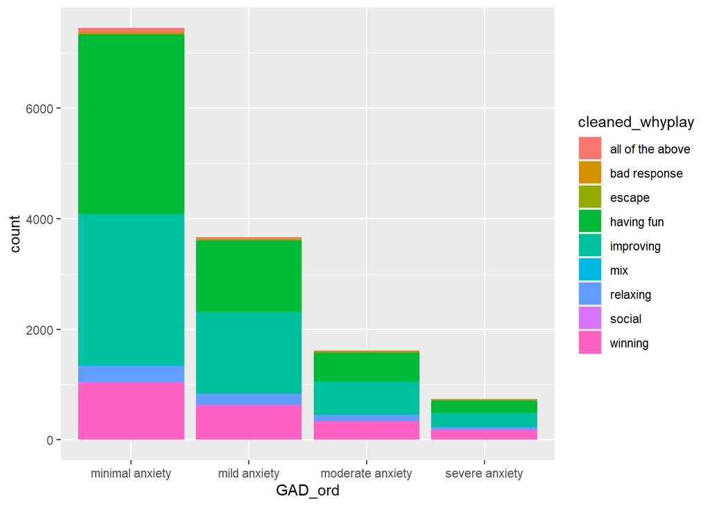

```r
ggplot(gaming_data, aes(x = GAD_ord, fill = cleaned_whyplay)) +
geom_bar()
```

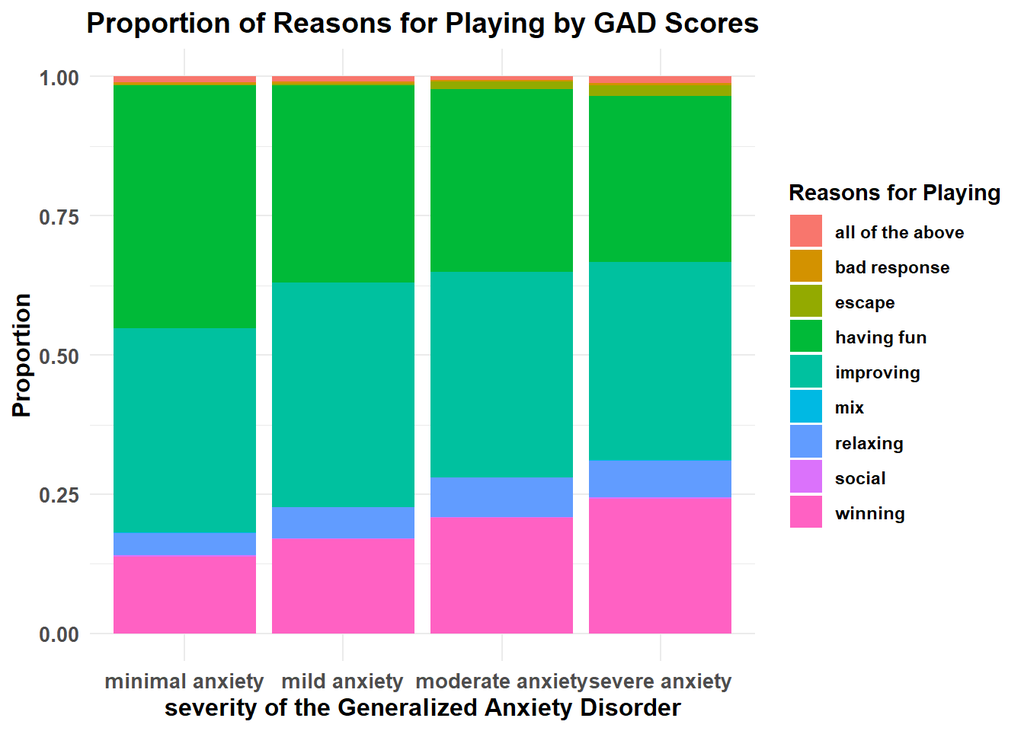

```r
ggplot(gaming_data, aes(x = GAD_ord, fill = cleaned_whyplay)) +
  geom_bar(position = "fill") +  # Use position = "fill" to show proportions
  ylab("Proportion") +           # Label the y-axis
  xlab("severity of the Generalized Anxiety Disorder") +           # Label the x-axis
  labs(title = "Proportion of Reasons for Playing by GAD Scores",
       fill = "Reasons for Playing") +  # Rename the legend title
  theme_minimal() +
  theme(
    plot.title = element_text(hjust = 0.5, face = "bold", size = 14),  # Center and bold the title
    axis.title.x = element_text(face = "bold", size = 12),  # Bold and size for x-axis label
    axis.title.y = element_text(face = "bold", size = 12),  # Bold and size for y-axis label
    axis.text.x = element_text(face = "bold", size = 10),   # Bold the x-axis tick labels
    axis.text.y = element_text(face = "bold", size = 10),   # Bold the y-axis tick labels
    legend.title = element_text(face = "bold"),             # Bold the legend title
    legend.text = element_text(face = "bold")               # Bold the legend labels
  )
```

# GADE_ordinal based on why they play

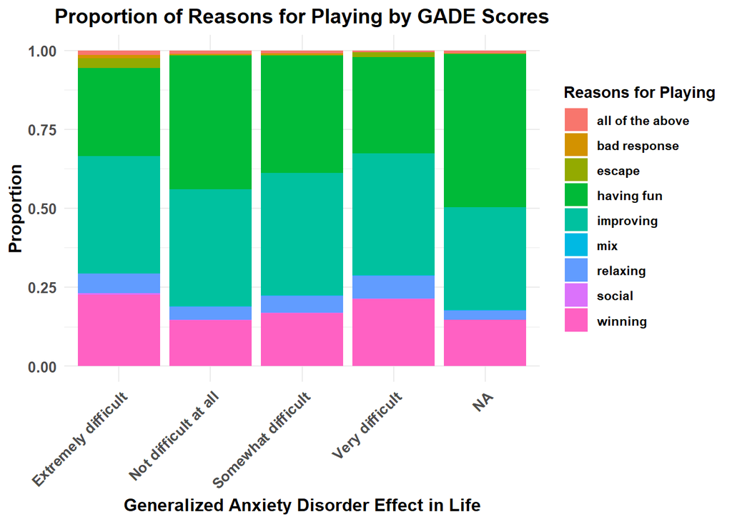

```r
ggplot(gaming_data, aes(x = GADE, fill = cleaned_whyplay)) +
  geom_bar(position = "fill") +  # Use position = "fill" to show proportions
  ylab("Proportion") +           # Label the y-axis
  xlab("Generalized Anxiety Disorder Effect in Life") +           # Label the x-axis
  labs(title = "Proportion of Reasons for Playing by GADE Scores",
       fill = "Reasons for Playing") +  # Rename the legend title
  theme_minimal() +
  theme(
    plot.title = element_text(hjust = 0.5, face = "bold", size = 14),  # Center and bold the title
    axis.title.x = element_text(face = "bold", size = 12),  # Bold and size for x-axis label
    axis.title.y = element_text(face = "bold", size = 12),  # Bold and size for y-axis label
    axis.text.x = element_text(face = "bold", size = 10, angle = 45, hjust = 1),   # Rotate and bold the x-axis tick labels
    axis.text.y = element_text(face = "bold", size = 10),   # Bold the y-axis tick labels
    legend.title = element_text(face = "bold"),             # Bold the legend title
    legend.text = element_text(face = "bold")               # Bold the legend labels
  )
```

# SPIN_ord_ordinal based on why they play

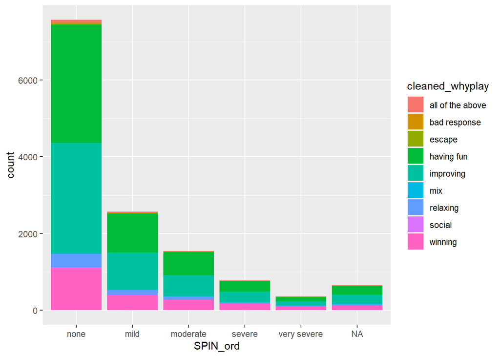

```r
ggplot(gaming_data, aes(x = SPIN_ord, fill = cleaned_whyplay)) +
geom_bar()
```

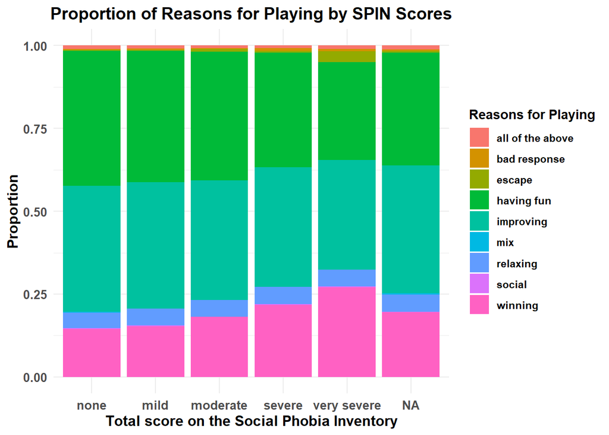

```r
ggplot(gaming_data, aes(x = SPIN_ord, fill = cleaned_whyplay)) +
  geom_bar(position = "fill") +  # Use position = "fill" to show proportions
  ylab("Proportion") +           # Label the y-axis
  xlab("Total score on the Social Phobia Inventory") +          # Label the x-axis
  labs(title = "Proportion of Reasons for Playing by SPIN Scores",
       fill = "Reasons for Playing") +  # Rename the legend title
  theme_minimal() +
  theme(
    plot.title = element_text(hjust = 0.5, face = "bold", size = 14),  # Center and bold the title
    axis.title.x = element_text(face = "bold", size = 12),  # Bold and size for x-axis label
    axis.title.y = element_text(face = "bold", size = 12),  # Bold and size for y-axis label
    axis.text.x = element_text(face = "bold", size = 10),   # Bold the x-axis tick labels
    axis.text.y = element_text(face = "bold", size = 10),   # Bold the y-axis tick labels
    legend.title = element_text(face = "bold"),             # Bold the legend title
    legend.text = element_text(face = "bold")               # Bold the legend labels
  )
```

# GAD_ordinal based on GADE

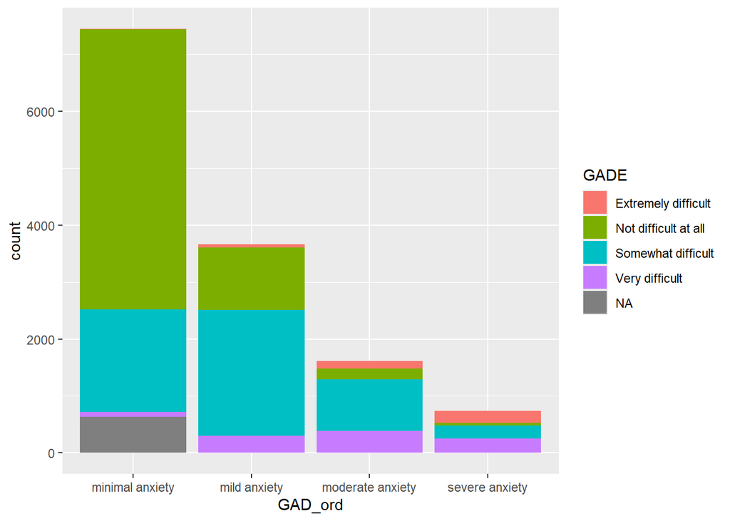

```r
ggplot(gaming_data, aes(x = GAD_ord, fill = GADE)) +
geom_bar()
```

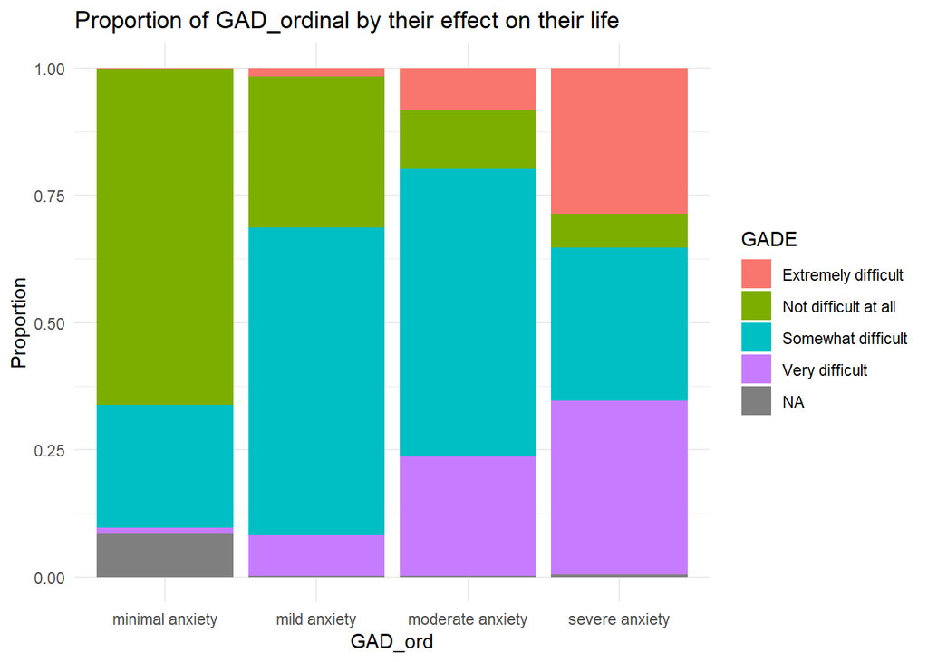

```r
ggplot(gaming_data, aes(x = GAD_ord, fill = GADE)) +
  geom_bar(position = "fill") +  # Use position = "fill" to show proportions
  ylab("Proportion") +            # Label the y-axis
  labs(title = "Proportion of GAD_ordinal by their effect on their life") +  # Add a title
  theme_minimal()
```

# Age (cleaned) distribution on GAD_ordinal based

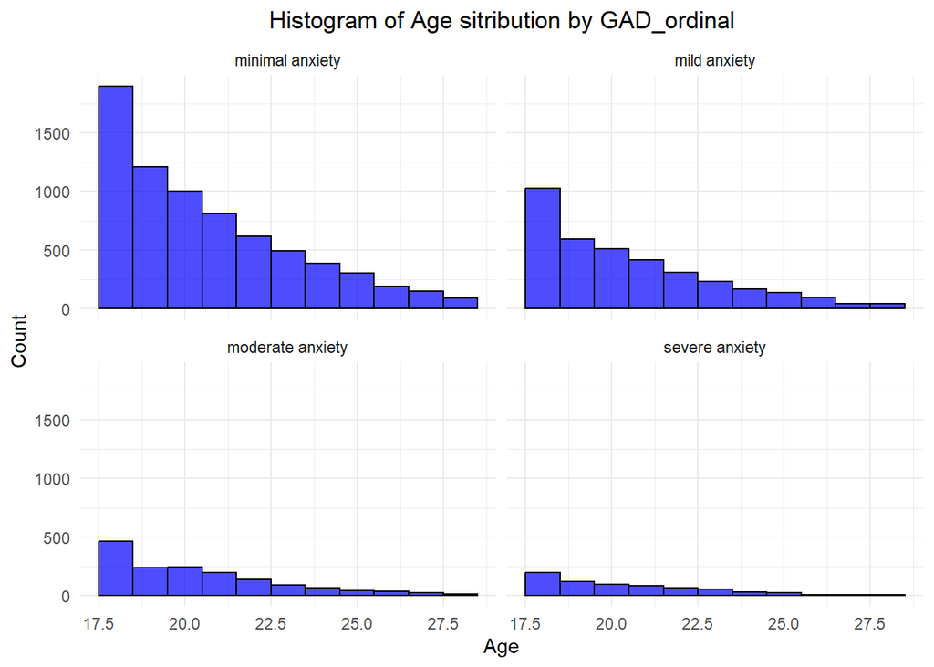

```r
ggplot(gaming_data, aes(x = gaming_data_clean$Age)) +
  geom_histogram(binwidth = 1, fill = "blue", color = "black", alpha = 0.7) +
  facet_wrap(~ GAD_ord) +
  labs(title = "Histogram of Age sitribution by GAD_ordinal",
       x = "Age",
       y = "Count") +
  theme_minimal() +
  theme(plot.title = element_text(hjust = 0.5))
```

# Hrs played distribution on GAD_ordinal based

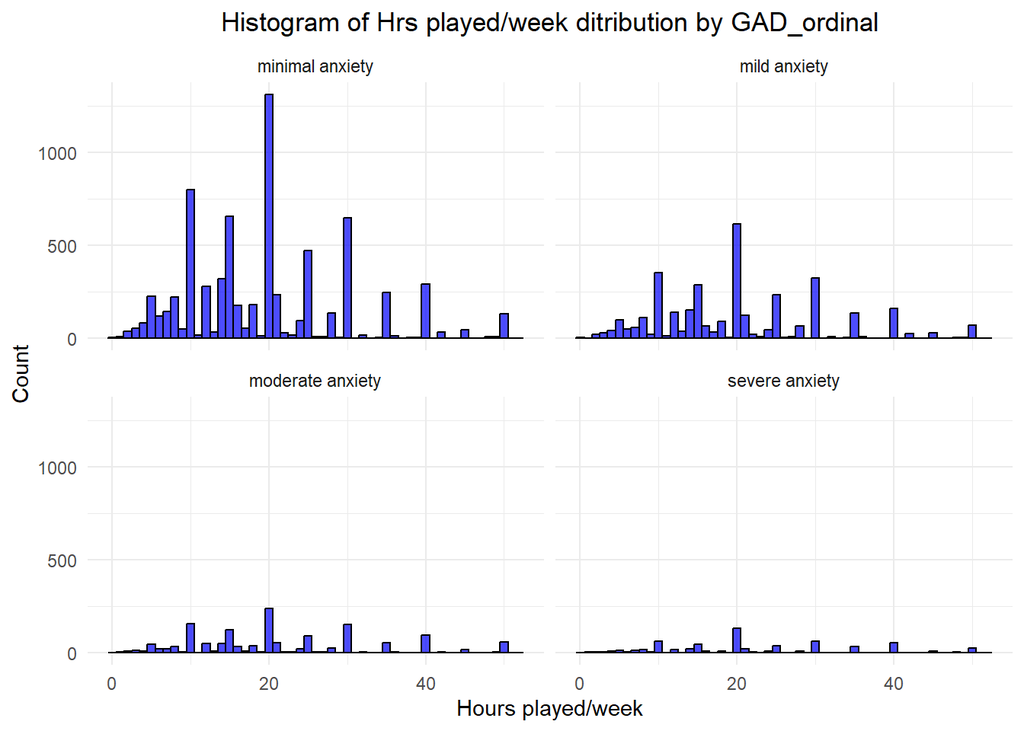

```r
ggplot(gaming_data, aes(x = hrs_GAD_filtered_clean$Hours)) +
  geom_histogram(binwidth = 1, fill = "blue", color = "black", alpha = 0.7) +
  facet_wrap(~ GAD_ord) +
  labs(title = "Histogram of Hrs played/week ditribution by GAD_ordinal",
       x = "Hours played/week",
       y = "Count") +
  theme_minimal() +
  theme(plot.title = element_text(hjust = 0.5))
```

# Hours played/week by SWL_ord

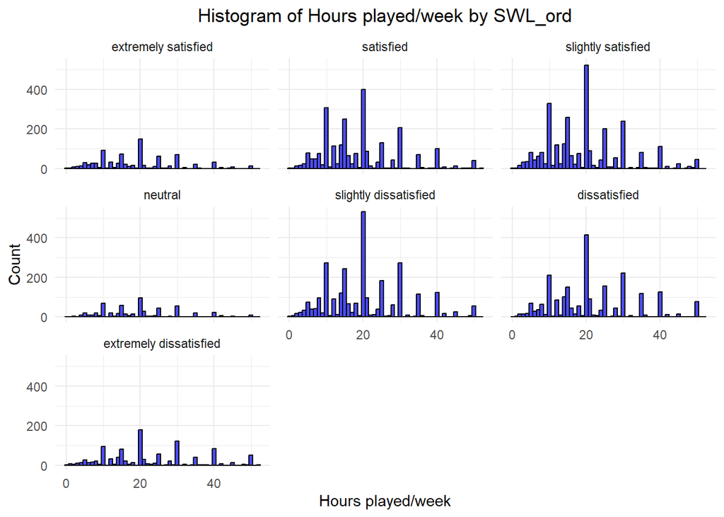

```r
ggplot(gaming_data, aes(x = hrs_GAD_filtered_clean$Hours)) +
  geom_histogram(binwidth = 1, fill = "blue", color = "black", alpha = 0.7) +
  facet_wrap(~ SWL_ord) +
  labs(title = "Histogram of Hours played/week by SWL_ord",
       x = "Hours played/week",
       y = "Count") +
  theme_minimal() +
  theme(plot.title = element_text(hjust = 0.5))
```

# Hours played/week by SPIN_ord

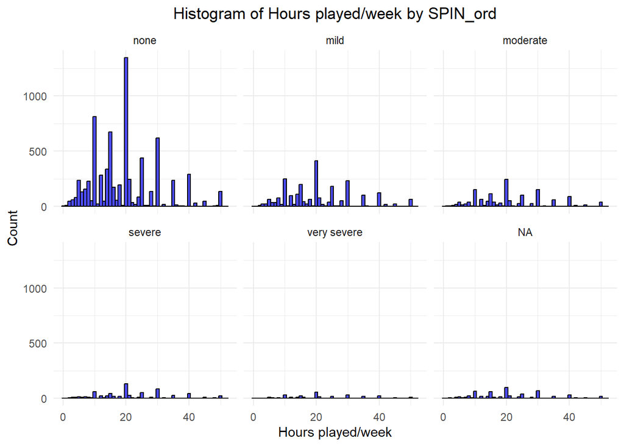

```r
ggplot(gaming_data, aes(x = hrs_GAD_filtered_clean$Hours)) +
  geom_histogram(binwidth = 1, fill = "blue", color = "black", alpha = 0.7) +
  facet_wrap(~ SPIN_ord) +
  labs(title = "Histogram of Hours played/week by SPIN_ord",
       x = "Hours played/week",
       y = "Count") +
  theme_minimal() +
  theme(plot.title = element_text(hjust = 0.5))
```

# Hours played/week by why_play

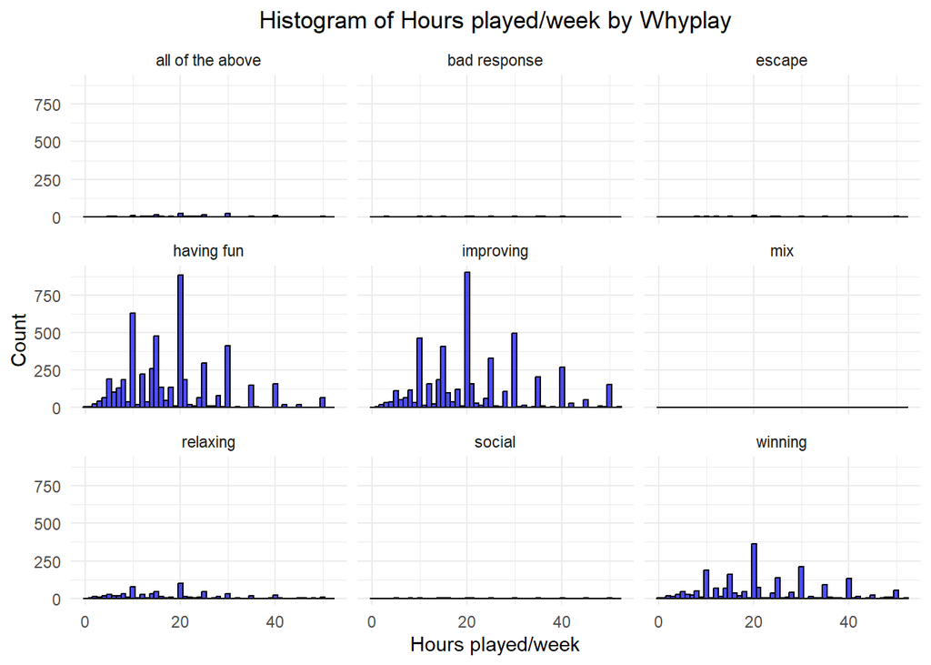

```r
ggplot(gaming_data, aes(x = hrs_GAD_filtered_clean$Hours)) +
  geom_histogram(binwidth = 1, fill = "blue", color = "black", alpha = 0.7) +
  facet_wrap(~ cleaned_whyplay) +
  labs(title = "Histogram of Hours played/week by Whyplay",
       x = "Hours played/week",
       y = "Count") +
  theme_minimal() +
  theme(plot.title = element_text(hjust = 0.5))
```

##Converting Narcicism to Ordinal >> Confused about the scale >> 1 indicates agree or disagree?

```r
# Function to convert Narcissism scores to ordinal variable
convert_narcissism <- function(score) {
  if (is.na(score)) return(NA)  # Handle NA values
  if (score == 1) {
    return("Not very true")
  } else if (score == 2) {
    return("Somewhat true")
  } else if (score == 3) {
    return("Moderately true")
  } else if (score == 4) {
    return("Mostly true")
  } else if (score == 5) {
    return("Very true")
  } else {
    return(NA)  # Handles scores outside defined range
  }
}

# Apply the function to the Narcissism column
gaming_data$Narcissism_ord <- sapply(gaming_data$Narcissism, convert_narcissism)

# Convert the result into an ordered factor
gaming_data$Narcissism_ord <- factor(gaming_data$Narcissism_ord,
                                     levels = c("Not very true", "Somewhat true", "Moderately true", "Mostly true", "Very true"),
                                     ordered = TRUE)

# Verify the conversion
table(gaming_data$Narcissism_ord)
```

```
##
##   Not very true   Somewhat true Moderately true     Mostly true       Very true
##            5259            4360            2341            1153             328
```

# Hours played/week by level of Narcissism

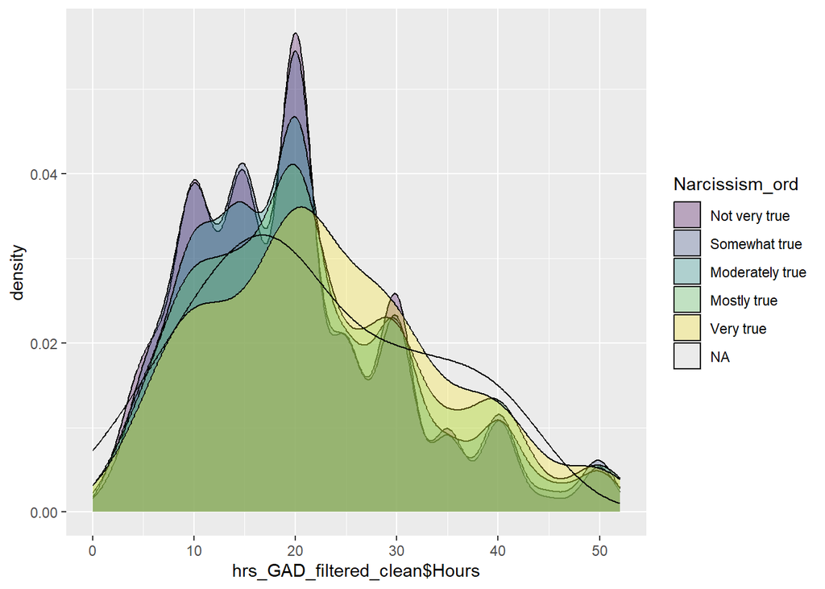

```r
ggplot(gaming_data, aes(x = hrs_GAD_filtered_clean$Hours, fill = Narcissism_ord)) +
geom_density(alpha = .3)
```

## Standardizing

```r
gaming_data_clean$streams_Stand <- scale(gaming_data_clean$streams)
hrs_GAD_filtered_clean$hours_Stand <- scale(hrs_GAD_filtered_clean$Hours)
gaming_data_clean$age_Stand <- scale(gaming_data_clean$Age)
```

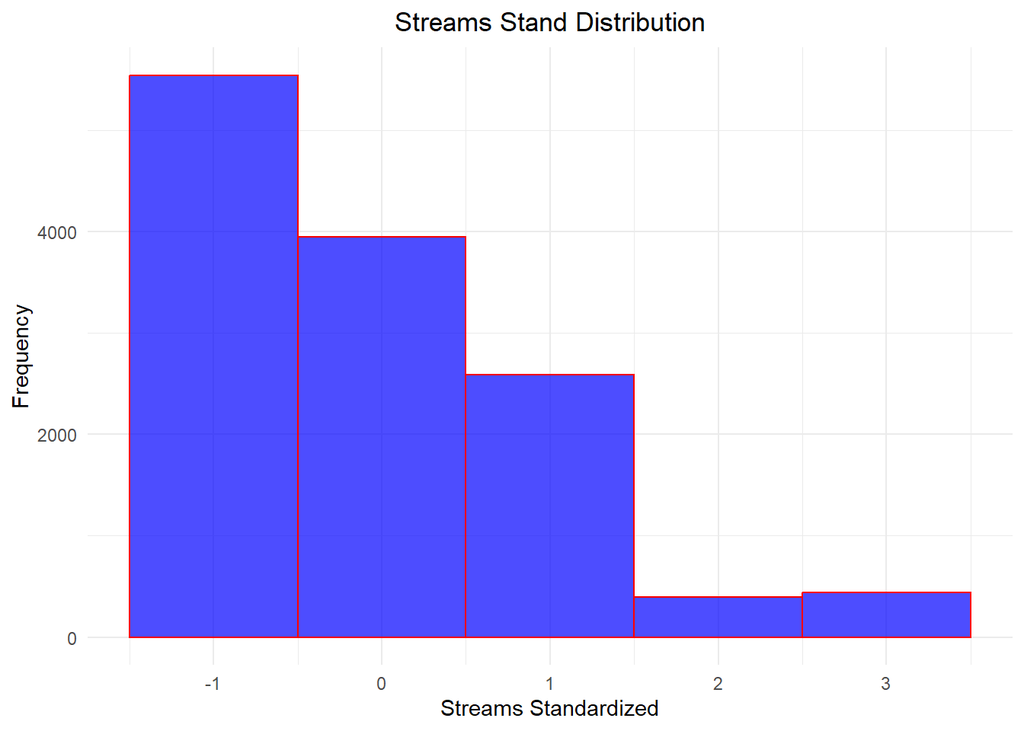

```r
# Histogram for standardized Streams
ggplot(data = gaming_data_clean, aes(x = streams_Stand)) +
  geom_histogram(binwidth = 1, color = "red", fill = "blue", alpha = .7) +
  labs(x = "Streams Standardized", y = "Frequency", title = "Streams Stand Distribution") +
  theme_minimal() +
  theme(plot.title = element_text(hjust = 0.5))
```

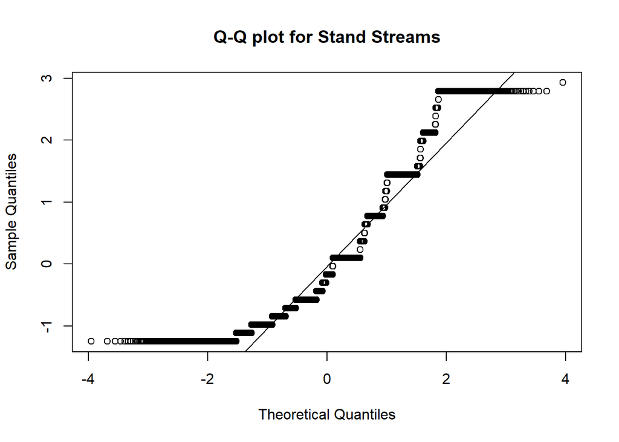

```r
# Q-Q plot for standardized Streams
qqnorm(gaming_data_clean$streams_Stand, main = "Q-Q plot for Stand Streams")
qqline(gaming_data_clean$streams_Stand)
```

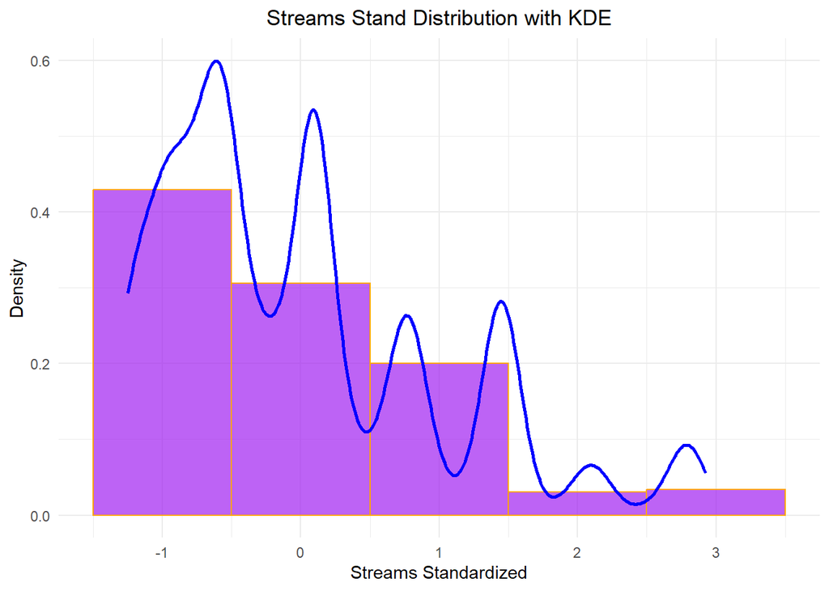

```r
# Histogram with KDE for standardized Streams
ggplot(data = gaming_data_clean, aes(x = streams_Stand)) +
  geom_histogram(aes(y = ..density..),  # Use density for y-axis
                 binwidth = 1,
                 color = "orange",
                 fill = "purple",
                 alpha = 0.7) +  # Opacity
  geom_density(color = "blue",           # Color of the KDE curve
               size = 1,                 # Thickness of the curve
               adjust = 1) +             # Adjust bandwidth for fitting
  labs(x = "Streams Standardized",
       y = "Density",                  # Change to Density for y-axis
       title = "Streams Stand Distribution with KDE") +
  theme_minimal() +
  theme(plot.title = element_text(hjust = 0.5))
```

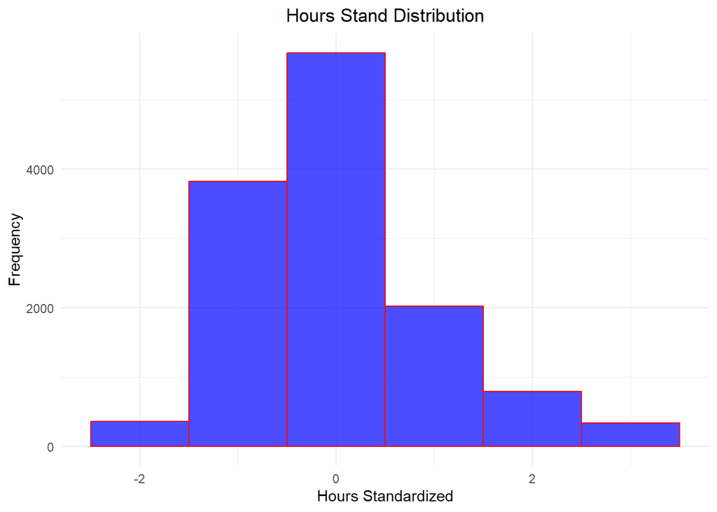

```r
# Histogram for standardized Hours
ggplot(data = hrs_GAD_filtered_clean, aes(x = hours_Stand)) +
  geom_histogram(binwidth = 1, color = "red", fill = "blue", alpha = .7) +
  labs(x = "Hours Standardized", y = "Frequency", title = "Hours Stand Distribution") +
  theme_minimal() +
  theme(plot.title = element_text(hjust = 0.5))
```

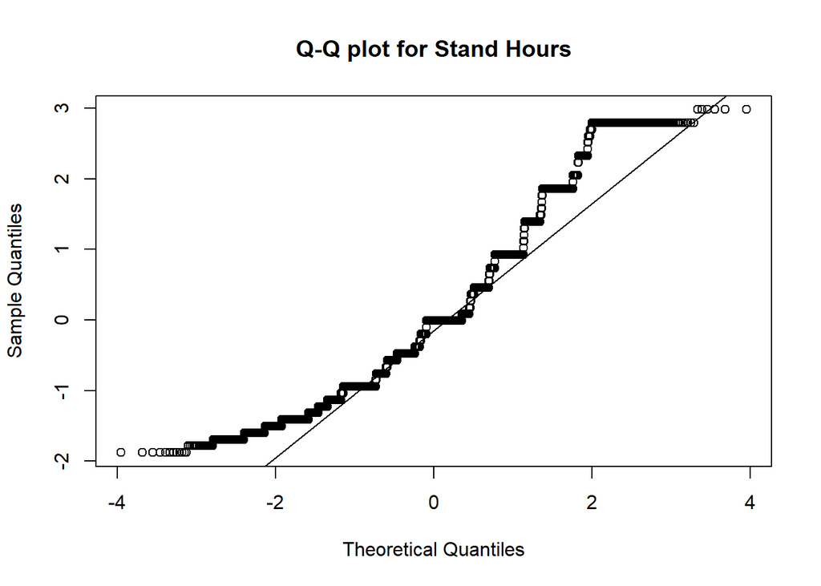

```r
# Q-Q plot for standardized Hours
qqnorm(hrs_GAD_filtered_clean$hours_Stand, main = "Q-Q plot for Stand Hours")
qqline(hrs_GAD_filtered_clean$hours_Stand)
```

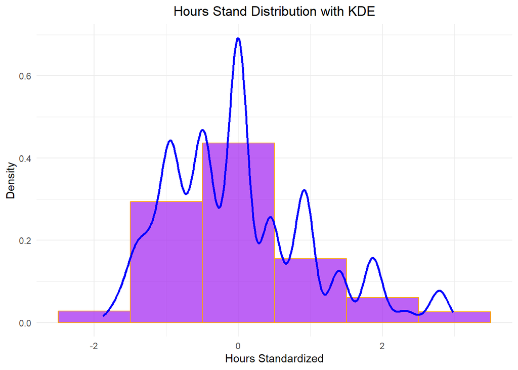

```r
# Histogram with KDE for standardized Hours
ggplot(data = hrs_GAD_filtered_clean, aes(x = hours_Stand)) +
  geom_histogram(aes(y = ..density..),  # Use density for y-axis
                 binwidth = 1,
                 color = "orange",
                 fill = "purple",
                 alpha = 0.7) +  # Opacity
  geom_density(color = "blue",           # Color of the KDE curve
               size = 1,                 # Thickness of the curve
               adjust = 1) +             # Adjust bandwidth for fitting
  labs(x = "Hours Standardized",
       y = "Density",                  # Change to Density for y-axis
       title = "Hours Stand Distribution with KDE") +
  theme_minimal() +
  theme(plot.title = element_text(hjust = 0.5))
```

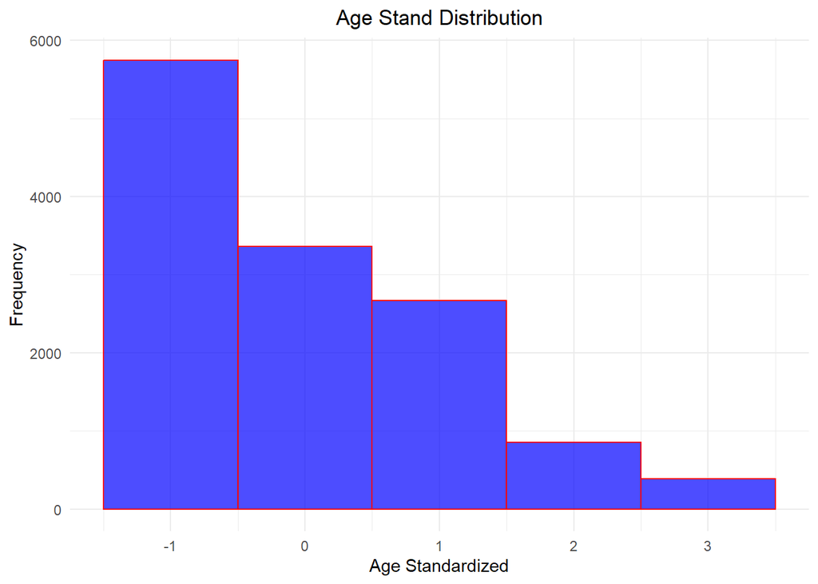

```r
# Histogram for standardized Age
ggplot(data = gaming_data_clean, aes(x = age_Stand)) +
  geom_histogram(binwidth = 1, color = "red", fill = "blue", alpha = .7) +
  labs(x = "Age Standardized", y = "Frequency", title = "Age Stand Distribution") +
  theme_minimal() +
  theme(plot.title = element_text(hjust = 0.5))
```

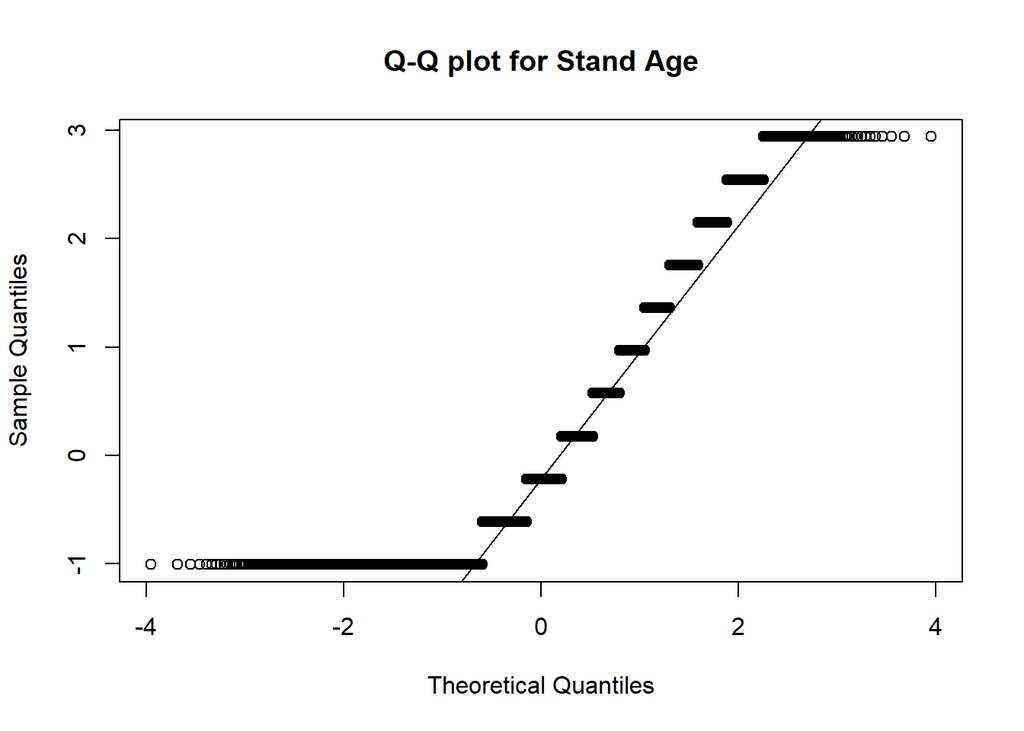

```r
# Q-Q plot for standardized Age
qqnorm(gaming_data_clean$age_Stand, main = "Q-Q plot for Stand Age")
qqline(gaming_data_clean$age_Stand)
```

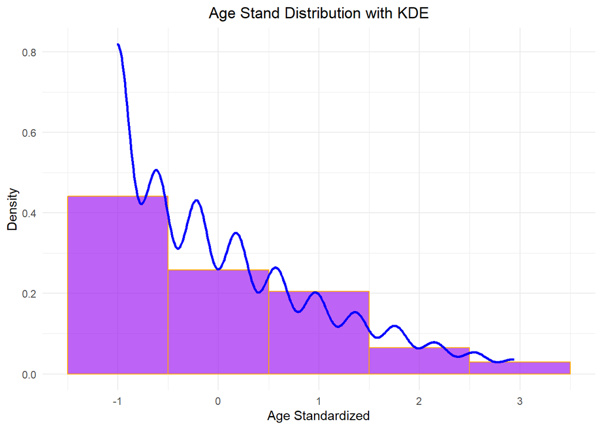

```r
# Histogram with KDE for standardized Age
ggplot(data = gaming_data_clean, aes(x = age_Stand)) +
  geom_histogram(aes(y = ..density..),  # Use density for y-axis
                 binwidth = 1,
                 color = "orange",
                 fill = "purple",
                 alpha = 0.7) +  # Opacity
  geom_density(color = "blue",           # Color of the KDE curve
               size = 1,                 # Thickness of the curve
               adjust = 1) +             # Adjust bandwidth for fitting
  labs(x = "Age Standardized",
       y = "Density",                  # Change to Density for y-axis
       title = "Age Stand Distribution with KDE") +
  theme_minimal() +
  theme(plot.title = element_text(hjust = 0.5))
```

# ANOVA test for hrs played and being narcissist

Null: There is no difference in the mean hours played among the different levels of narcissism. Alternate: At least one group mean is different from the others.

```r
# Combine the two datasets (assuming both have a common identifier or are appropriately merged)
combined_data <- data.frame(Narcissism = gaming_data$Narcissism_ord,
                            Hours = hrs_GAD_filtered_clean$Hours)

# Conduct ANOVA
anova_result <- aov(Hours ~ Narcissism, data = combined_data)

# Summarize the ANOVA results
summary(anova_result)
```

```
##                Df  Sum Sq Mean Sq F value   Pr(>F)
## Narcissism      4    7337  1834.3   16.11 3.66e-13 ***
## Residuals   12989 1479196   113.9
## ---
## Signif. codes:  0 '***' 0.001 '**' 0.01 '*' 0.05 '.' 0.1 ' ' 1
## 470 observations deleted due to missingness
```

Since the p-value is less than 0.001 (indicated by the ***), we conclude that there are statistically significant differences in hours of gameplay among the different levels of narcissism - suggesting that the amount of time spent gaming is influenced by an individual’s level of narcissism.

# post-hoc test

```r
# Perform the ANOVA
anova_result <- aov(Hours ~ Narcissism, data = combined_data)

# Summarize the ANOVA results
summary(anova_result)
```

```
##                Df  Sum Sq Mean Sq F value   Pr(>F)
## Narcissism      4    7337  1834.3   16.11 3.66e-13 ***
## Residuals   12989 1479196   113.9
## ---
## Signif. codes:  0 '***' 0.001 '**' 0.01 '*' 0.05 '.' 0.1 ' ' 1
## 470 observations deleted due to missingness
```

```r
# Conduct the post-hoc Tukey HSD test
posthoc_result <- TukeyHSD(anova_result)

# Print the post-hoc test results
print(posthoc_result)
```

```
##   Tukey multiple comparisons of means
##     95% family-wise confidence level
##
## Fit: aov(formula = Hours ~ Narcissism, data = combined_data)
##
## $Narcissism
##                                    diff         lwr       upr     p adj
## Somewhat true-Not very true   0.2435323 -0.36231600 0.8493806 0.8083753
## Moderately true-Not very true 0.9278545  0.19241829 1.6632906 0.0052466
## Mostly true-Not very true     2.1003949  1.13794406 3.0628458 0.0000000
## Very true-Not very true       3.4052649  1.67001289 5.1405169 0.0000009
## Moderately true-Somewhat true 0.6843221 -0.07349372 1.4421380 0.0990859
## Mostly true-Somewhat true     1.8568626  0.87720441 2.8365208 0.0000023
## Very true-Somewhat true       3.1617326  1.41687785 4.9065873 0.0000077
## Mostly true-Moderately true   1.1725405  0.10786005 2.2372209 0.0223820
## Very true-Moderately true     2.4774105  0.68343936 4.2713815 0.0015551
## Very true-Mostly true         1.3048700 -0.59349184 3.2032318 0.3307694
```

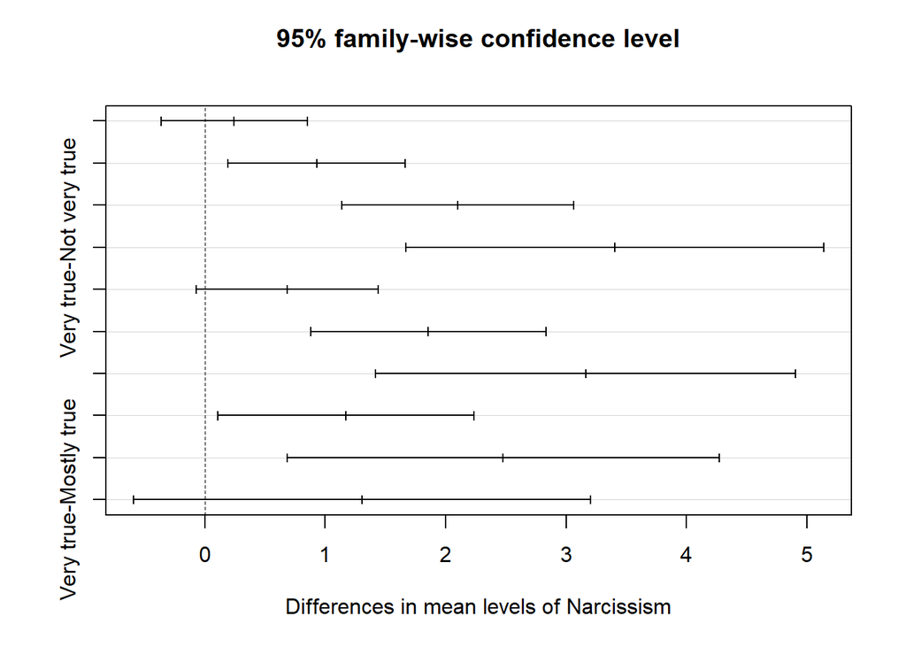

```r
# Optionally, visualize the results of the post-hoc test
plot(posthoc_result)
```

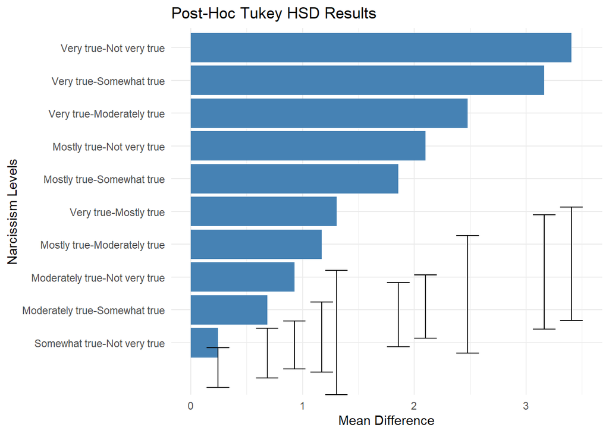

```r
# Convert the Tukey HSD results to a data frame
posthoc_df <- as.data.frame(posthoc_result$Narcissism)

# Plot the results
ggplot(posthoc_df, aes(y = reorder(rownames(posthoc_df), diff), x = diff)) +
  geom_bar(stat = "identity", fill = "steelblue") +
  geom_errorbar(aes(ymin = lwr, ymax = upr), width = 0.2) +
  labs(y = "Narcissism Levels", x = "Mean Difference", title = "Post-Hoc Tukey HSD Results") +
  theme_minimal()
```

# ANOVA test for hrs played and GAD

Null Hypothesis: No significant difference in the mean hours played per week across the different levels of Generalized Anxiety Disorder (GAD). Alternate: There is at least one significant difference in the mean hours played per week across the different levels of Generalized Anxiety Disorder (GAD).

```r
anova_result <- aov(hrs_GAD_filtered_clean$Hours ~ gaming_data$GAD_ord)

# Summary of the ANOVA test results
summary(anova_result)
```

```
##                        Df  Sum Sq Mean Sq F value   Pr(>F)
## gaming_data$GAD_ord     3    7602  2534.0   22.25 2.29e-14 ***
## Residuals           13012 1481686   113.9
## ---
## Signif. codes:  0 '***' 0.001 '**' 0.01 '*' 0.05 '.' 0.1 ' ' 1
## 448 observations deleted due to missingness
```

p-value is much less than the significance level of 0.05, means that there is at least one significant difference in the mean hours played per week across the different levels of Generalized Anxiety Disorder (GAD).

# post-hoc test

```r
# Perform the ANOVA
anova_result <- aov(hrs_GAD_filtered_clean$Hours ~ gaming_data$GAD_ord)

# Summary of the ANOVA test results
summary(anova_result)
```

```
##                        Df  Sum Sq Mean Sq F value   Pr(>F)
## gaming_data$GAD_ord     3    7602  2534.0   22.25 2.29e-14 ***
## Residuals           13012 1481686   113.9
## ---
## Signif. codes:  0 '***' 0.001 '**' 0.01 '*' 0.05 '.' 0.1 ' ' 1
## 448 observations deleted due to missingness
```

```r
# Conduct the post-hoc Tukey HSD test
posthoc_result <- TukeyHSD(anova_result)

# Print the post-hoc test results
print(posthoc_result)
```

```
##   Tukey multiple comparisons of means
##     95% family-wise confidence level
##
## Fit: aov(formula = hrs_GAD_filtered_clean$Hours ~ gaming_data$GAD_ord)
##
## $`gaming_data$GAD_ord`
##                                       diff         lwr      upr     p adj
## mild anxiety-minimal anxiety     0.5954192  0.03386756 1.156971 0.0326985
## moderate anxiety-minimal anxiety 1.7953554  1.02484161 2.565869 0.0000000
## severe anxiety-minimal anxiety   2.6672387  1.56615104 3.768326 0.0000000
## moderate anxiety-mild anxiety    1.1999362  0.36223508 2.037637 0.0013361
## severe anxiety-mild anxiety      2.0718195  0.92271302 3.220926 0.0000216
## severe anxiety-moderate anxiety  0.8718833 -0.39255205 2.136319 0.2870731
```

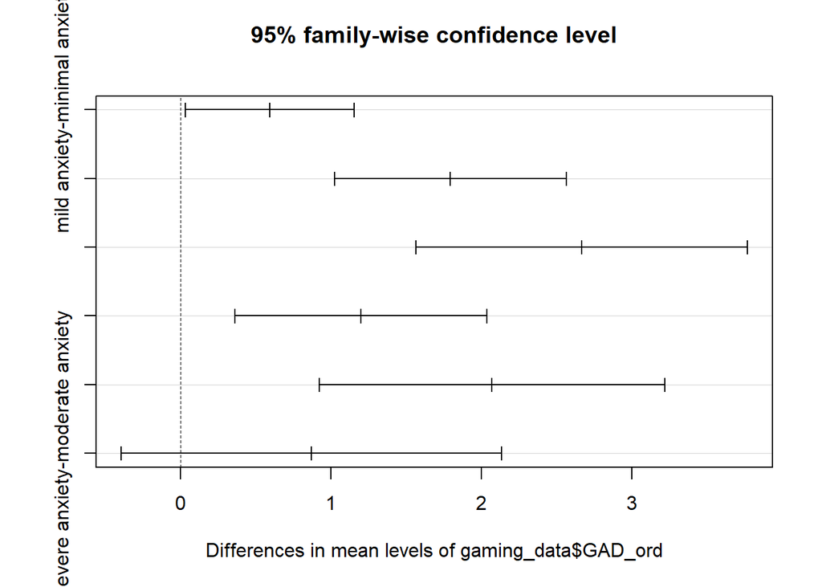

```r
# Optionally, visualize the results of the post-hoc test
plot(posthoc_result)
```

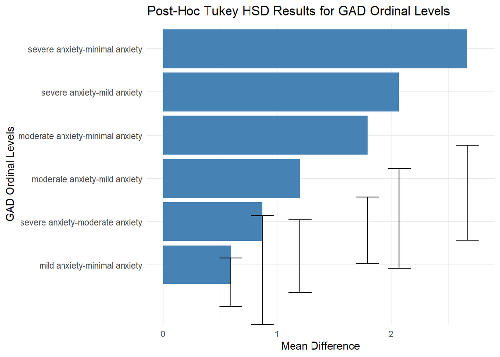

```r
# Convert the Tukey HSD results to a data frame for easier manipulation
posthoc_df <- as.data.frame(posthoc_result$`gaming_data$GAD_ord`)

# Plotting the post-hoc test results
library(ggplot2)

ggplot(posthoc_df, aes(y = reorder(rownames(posthoc_df), diff), x = diff)) +
  geom_bar(stat = "identity", fill = "steelblue") +
  geom_errorbar(aes(ymin = lwr, ymax = upr), width = 0.2) +
  labs(y = "GAD Ordinal Levels", x = "Mean Difference", title = "Post-Hoc Tukey HSD Results for GAD Ordinal Levels") +
  theme_minimal()
```

# Adding Hours and Streams, and creating histogram

```r
# Create the new column hrs_stream_combined in gaming_data
gaming_data$hrs_stream_combined <- gaming_data_clean$streams + hrs_GAD_filtered_clean$Hours

# Check the structure of the updated gaming_data
str(gaming_data)
```

```
## 'data.frame':    13464 obs. of  61 variables:
##  $ S..No.             : int  1 2 3 4 5 6 7 8 9 10 ...
##  $ Timestamp          : num  42052 42052 42052 42052 42052 ...
##  $ GAD1               : int  0 1 0 0 2 0 0 0 2 2 ...
##  $ GAD2               : int  0 2 2 0 1 0 0 0 3 1 ...
##  $ GAD3               : int  0 2 2 0 2 0 0 0 2 2 ...
##  $ GAD4               : int  0 2 0 0 2 0 0 0 2 2 ...
##  $ GAD5               : int  1 0 0 0 2 0 0 0 0 2 ...
##  $ GAD6               : int  0 1 3 0 3 1 0 0 1 1 ...
##  $ GAD7               : int  0 0 1 0 2 0 0 0 2 0 ...
##  $ GADE               : chr  "Not difficult at all" "Somewhat difficult" "Not difficult at all" "Not difficult at all" ...
##  $ SWL1               : int  3 3 2 2 2 3 3 3 2 3 ...
##  $ SWL2               : int  5 5 6 5 2 5 4 6 3 3 ...
##  $ SWL3               : int  5 2 5 5 4 3 4 4 3 3 ...
##  $ SWL4               : int  5 5 2 3 5 3 3 3 3 2 ...
```

[output cut: 47 more lines]

```r
# View the first few rows to verify the new column
head(gaming_data)
```

```
##   S..No. Timestamp GAD1 GAD2 GAD3 GAD4 GAD5 GAD6 GAD7                 GADE SWL1
## 1      1  42052.00    0    0    0    0    1    0    0 Not difficult at all    3
## 2      2  42052.01    1    2    2    2    0    1    0   Somewhat difficult    3
## 3      3  42052.04    0    2    2    0    0    3    1 Not difficult at all    2
## 4      4  42052.07    0    0    0    0    0    0    0 Not difficult at all    2
## 5      5  42052.09    2    1    2    2    2    3    2       Very difficult    2
## 6      6  42052.13    0    0    0    0    0    1    0 Not difficult at all    3
##   SWL2 SWL3 SWL4 SWL5   Game                Platform Hours       earnings
## 1    5    5    5    5 Skyrim Console (PS, Xbox, ...)    15 I play for fun
## 2    5    2    5    1  Other                      PC     8 I play for fun
## 3    6    5    2    2  Other                      PC     0 I play for fun
## 4    5    5    3    2  Other                      PC    20 I play for fun
## 5    2    4    5    1  Other Console (PS, Xbox, ...)    20 I play for fun
## 6    5    3    3    3  Other Console (PS, Xbox, ...)     4 I play for fun
##      whyplay League highestleague streams SPIN1 SPIN2 SPIN3 SPIN4 SPIN5 SPIN6
```

[output cut: 48 more lines]

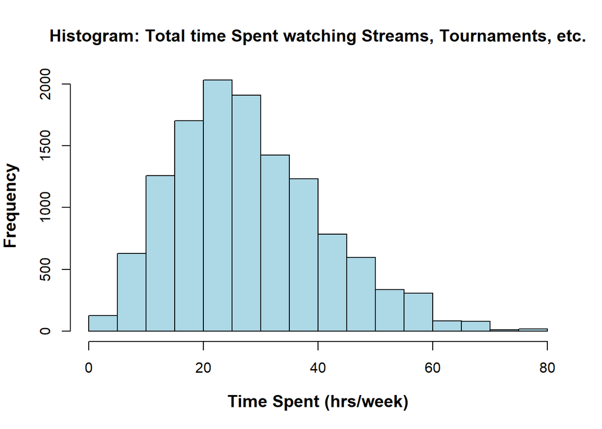

```r
hist(gaming_data$hrs_stream_combined,
     main = "", # Set an empty main to customize it later
     xlab = "", # Set an empty xlab to customize it later
     ylab = "", # Set an empty ylab to customize it later
     col = "lightblue")

# Customize the title and labels
title(main = "Histogram: Total time Spent watching Streams, Tournaments, etc.",
      xlab = "Time Spent (hrs/week)",
      ylab = "Frequency",        # Add the y-axis label
      font.main = 2,  # Bold title
      font.lab = 2,   # Bold x and y labels
      cex.main = 1.2, # Adjust title size
      cex.lab = 1.2   # Adjust label size for both axes
)
```

# Hrs, Streaming_combined distribution on GAD_ordinal based

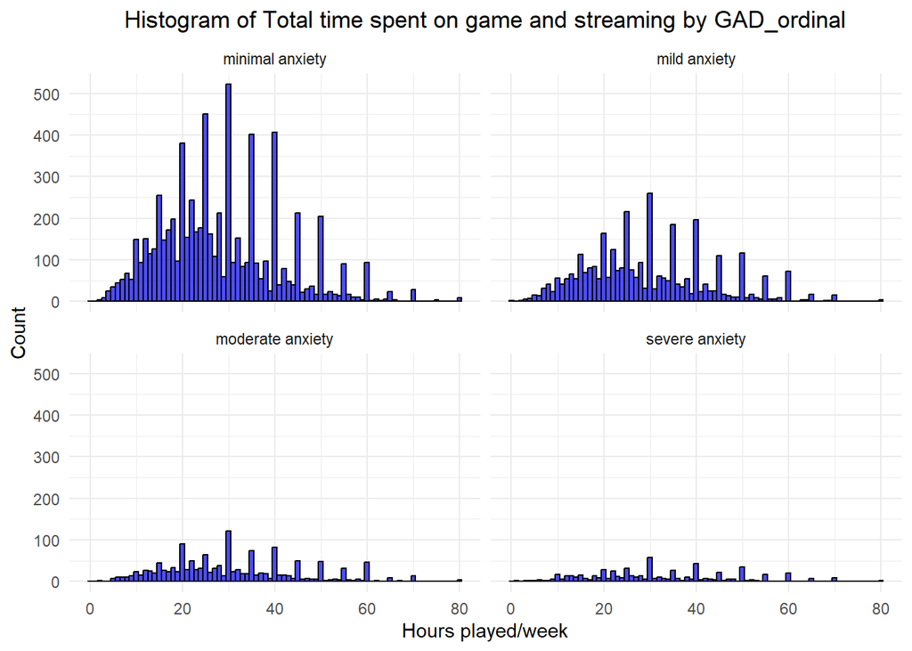

```r
ggplot(gaming_data, aes(x = gaming_data$hrs_stream_combined)) +
  geom_histogram(binwidth = 1, fill = "blue", color = "black", alpha = 0.7) +
  facet_wrap(~ GAD_ord) +
  labs(title = "Histogram of Total time spent on game and streaming by GAD_ordinal",
       x = "Hours played/week",
       y = "Count") +
  theme_minimal() +
  theme(plot.title = element_text(hjust = 0.5))
```

# ANOVA test for Total time spend and GAD_T

Null: There is no difference in the mean combined hours spent on gaming and streaming among the different levels of GAD. Alternate: At least one group mean of the combined hours spent on gaming and streaming is different from the others among the different levels of GAD.

```r
# Combine the hours played and streams into a new variable
gaming_data$hrs_stream_combined <- gaming_data_clean$streams + hrs_GAD_filtered_clean$Hours

# Perform the ANOVA test
anova_result_combined <- aov(hrs_stream_combined ~ GAD_ord, data = gaming_data)

# Summarize the ANOVA results
summary(anova_result_combined)
```

```
##                Df  Sum Sq Mean Sq F value   Pr(>F)
## GAD_ord         3   13618    4539   24.95 4.32e-16 ***
## Residuals   12530 2279229     182
## ---
## Signif. codes:  0 '***' 0.001 '**' 0.01 '*' 0.05 '.' 0.1 ' ' 1
## 930 observations deleted due to missingness
```

p values small so we reject the null hypothesis. This indicates that there is a statistically significant difference in the mean combined hours spent on gaming and streaming among the different levels of GAD.

#Post hoc test

```r
# Perform the ANOVA
anova_result <- aov(hrs_stream_combined ~ GAD_ord, data = gaming_data)

# Perform Tukey HSD post-hoc test
tukey_result <- TukeyHSD(anova_result)

# Display the Tukey HSD results
print(tukey_result)
```

```
##   Tukey multiple comparisons of means
##     95% family-wise confidence level
##
## Fit: aov(formula = hrs_stream_combined ~ GAD_ord, data = gaming_data)
##
## $GAD_ord
##                                      diff         lwr      upr     p adj
## mild anxiety-minimal anxiety     1.092205  0.36889041 1.815520 0.0006080
## moderate anxiety-minimal anxiety 2.235694  1.23931857 3.232068 0.0000000
## severe anxiety-minimal anxiety   3.833933  2.39798865 5.269878 0.0000000
## moderate anxiety-mild anxiety    1.143488  0.05983309 2.227144 0.0339287
## severe anxiety-mild anxiety      2.741728  1.24390213 4.239554 0.0000154
## severe anxiety-moderate anxiety  1.598240 -0.04889756 3.245377 0.0610155
```

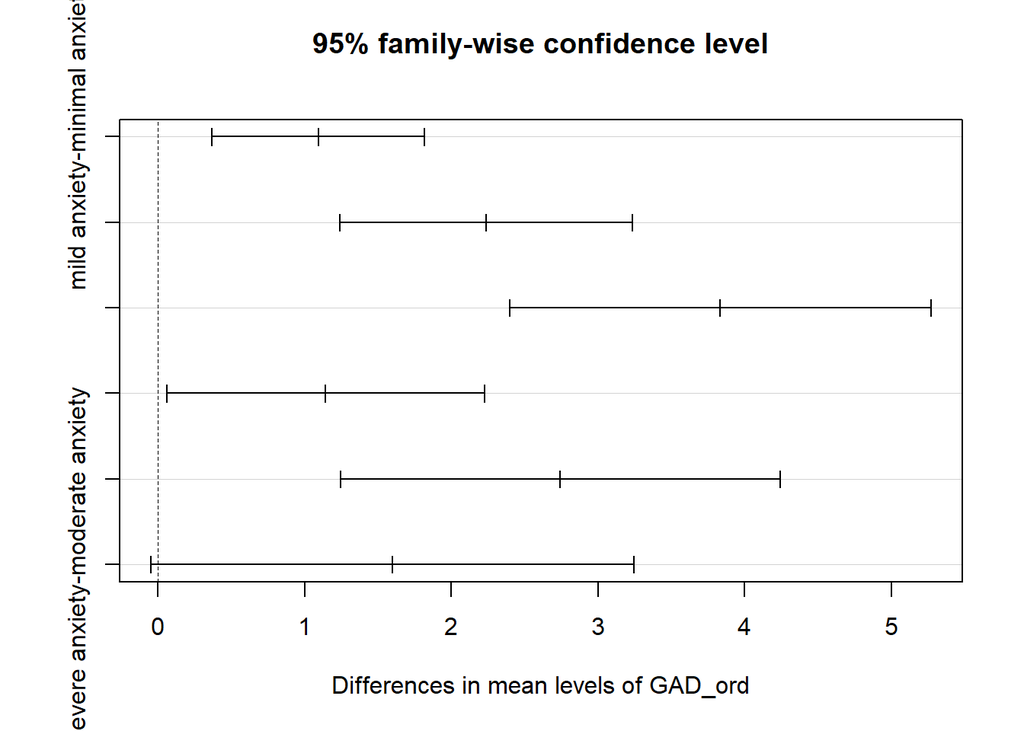

```r
# Optional: Plot the Tukey HSD results
plot(tukey_result)
```